# BBRF GMM: Latent Daily Psychophysiological States & Suicide Risk

## Analysis Overview

Goal is to discover latent daily states from a small set of continuous psychophysiological features (i.e., mood, actigraphy derived sleep, go/no-go cognition) by fitting a Gaussian Mixture Model via EM, then characterize those states by their suicidal-ideation profiles and analyze how individuals move among them over time

**This will occur in three stages.**

1. *Univariate EM (EDA + code stepping-stone).* Fit a 1-D GMM to each feature to inspect multimodality before committing to the joint model. We also run a pre-registered check on the go/no-go commission feature and document its eventual exclusion from the mixture
2. *Multivariate GMM (the model).* Fit the joint mixture; select K by comparing BIC, AIC, and ICL (with classification entropy and the smallest mixing weight as degeneracy diagnostics), a Kneedle knee, a marginal density-fit comparison, and the person x state artifact check
3. *States + dynamics.* Overlay SI/SB onto states; decode per-person state sequences; relate early-warning indicators (variance, lag-1 autocorrelation) to transitions into high-SI states

```
Modeling on 644 complete person-days across 30 subjects (of 813 total person-days). Modeling features: depression, anxiety, sleep_eff, hrs_to_sleep, sleep_totalmin.
```

## 1. Univariate EM (per-feature multimodality)

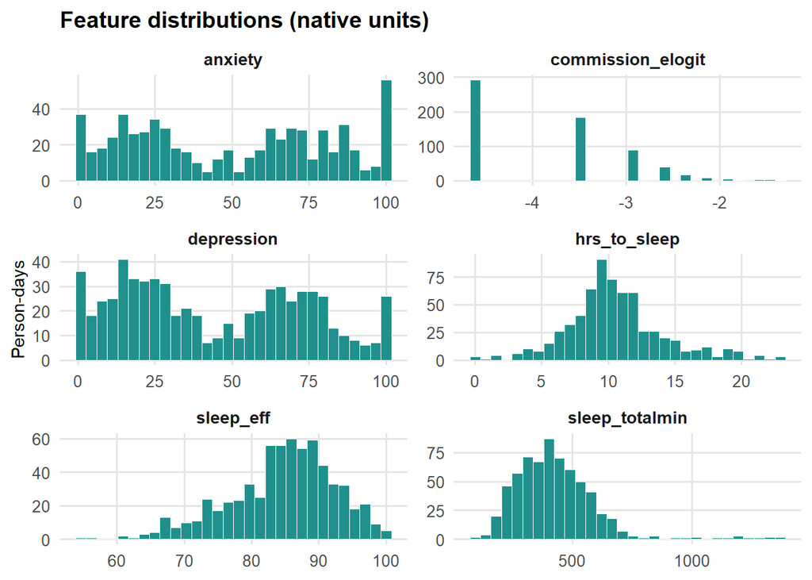

Feature shape summary (skew + floor share)

| feature | n | mean | sd | skew | pct_at_floor |
| --- | --- | --- | --- | --- | --- |
| anxiety | 644 | 49.470 | 31.850 | 0.064 | 5.4 |
| commission_elogit | 644 | -3.786 | 0.843 | 0.484 | 45.3 |
| depression | 644 | 44.234 | 29.277 | 0.221 | 5.4 |
| hrs_to_sleep | 644 | 10.535 | 3.631 | 0.579 | 0.2 |
| sleep_eff | 644 | 84.556 | 7.883 | -0.612 | 0.2 |
| sleep_totalmin | 644 | 428.505 | 177.605 | 1.922 | 0.2 |

```r
## Fit a 2-component 1-D GMM to each feature as exploratory structure check ##

uni_fits <- purrr::map(feat, function(v) {
  x <- model_df[[v]]
  x <- x[is.finite(x)]
  gmm_em_fit_1d(x, K = 2L, n_restarts = cfg$gmm$n_restarts, seed = cfg$gmm$seed)
})

names(uni_fits) <- feat

#1.1 Summarize each feature's recovered component means / weights
uni_summary <- purrr::imap_dfr(uni_fits, function(f, nm) {
  ord <- order(f$mu)
  tibble::tibble(
    feature = nm,
    mu_low = f$mu[ord][1], mu_high = f$mu[ord][2],
    sd_low = sqrt(f$sigma2[ord][1]), sd_high = sqrt(f$sigma2[ord][2]),
    w_low = f$weights[ord][1], w_high  = f$weights[ord][2],
    separation = abs(diff(f$mu)) / sqrt(mean(f$sigma2)))
})

nice_tbl(uni_summary, caption = "Univariate 2-component summaries", digits = 3)
```

Univariate 2-component summaries

| feature | mu_low | mu_high | sd_low | sd_high | w_low | w_high | separation |
| --- | --- | --- | --- | --- | --- | --- | --- |
| depression | 18.753 | 70.260 | 11.294 | 16.098 | 0.505 | 0.495 | 3.704 |
| anxiety | 18.744 | 75.308 | 11.710 | 16.964 | 0.457 | 0.543 | 3.881 |
| sleep_eff | 77.157 | 88.090 | 7.349 | 5.219 | 0.323 | 0.677 | 1.715 |
| hrs_to_sleep | 9.753 | 11.328 | 1.720 | 4.718 | 0.504 | 0.496 | 0.443 |
| commission_elogit | -4.615 | -3.098 | 0.010 | 0.504 | 0.453 | 0.547 | 4.258 |
| sleep_totalmin | 408.475 | 1114.233 | 131.204 | 190.833 | 0.972 | 0.028 | 4.310 |

## Commission error documented exclusion check

```r
## Why commission is an overlay, not a mixture input ##

if ("commission_elogit" %in% feat) {

  #C.1 Fit on commission-complete days, on the FULL feature set, at a documented K
  doc_rows <- which(stats::complete.cases(model_df[, feat]))
  X_doc <- zscore_matrix(model_df[doc_rows, feat])
  k_doc <- cfg$gmm$commission_doc_k

  fit_doc <- gmm_em_fit(X_doc, K = k_doc, n_restarts = cfg$gmm$n_restarts,
                        max_iter = cfg$gmm$max_iter, tol = cfg$gmm$tol,
                        ridge = cfg$gmm$ridge, seed = cfg$gmm$seed)

  #C.2 Commission dominates discrimination via near-zero within-component variance
  nice_tbl(gmm_feature_discrimination(fit_doc, X_doc),
           caption = glue::glue("Commission INCLUDED (K = {k_doc}): per-feature discrimination ",
                               "(commission's ratio is inflated by a near-zero-variance spike)"))

  #C.3 States whose commission var_z sits at the ridge are the
  #    degenerate zero-error spike(s)
  ci <- which(colnames(X_doc) == "commission_elogit")
  nice_tbl(tibble::tibble(
    state = factor(seq_len(fit_doc$K)),
    mean_z = round(fit_doc$mu[, ci], 2),
    var_z = round(vapply(fit_doc$Sigma, function(S) S[ci, ci], numeric(1)), 4),
    weight = round(fit_doc$weights, 3)),
    caption = "commission_elogit by state (var_z near the GMM ridge => degenerate spike)")

} else {
  message("commission_elogit not in the configured feature set; skipping documented check.")
}
```

commission_elogit by state (var_z near the GMM ridge => degenerate spike)

| state | mean_z | var_z | weight |
| --- | --- | --- | --- |
| 1 | 1.32 | 0.236 | 0.251 |
| 2 | 0.34 | 0.000 | 0.281 |
| 3 | 0.39 | 1.402 | 0.024 |
| 4 | -0.98 | 0.000 | 0.444 |

## 2. Multivariate GMM + model selection

```r
## Fit across K; compare BIC, AIC, ICL (+ entropy, smallest mixing weight) ##

sel <- gmm_select_k(
  X,
  k_range = unlist(cfg$gmm$k_range),
  n_restarts = cfg$gmm$n_restarts,
  max_iter = cfg$gmm$max_iter,
  tol = cfg$gmm$tol,
  ridge = cfg$gmm$ridge,
  seed = cfg$gmm$seed)

nice_tbl(sel$bic_table,
         caption = "Model selection across K (BIC, AIC, ICL, entropy, min mixing weight)",
         digits = 1)
```

Model selection across K (BIC, AIC, ICL, entropy, min mixing weight)

| K | log_lik | n_params | bic | aic | icl | entropy | min_weight | converged | iterations |
| --- | --- | --- | --- | --- | --- | --- | --- | --- | --- |
| 1 | -4323.1 | 20 | 8775.5 | 8686.1 | 8775.5 | 0.0 | 1.0 | TRUE | 3 |
| 2 | -4143.8 | 41 | 8552.8 | 8369.6 | 8637.1 | 42.1 | 0.1 | TRUE | 66 |
| 3 | -3995.8 | 62 | 8392.5 | 8115.5 | 8619.9 | 113.7 | 0.1 | TRUE | 228 |
| 4 | -3906.5 | 83 | 8349.8 | 7979.0 | 8593.8 | 122.0 | 0.0 | TRUE | 326 |
| 5 | -3827.7 | 104 | 8328.1 | 7863.5 | 8672.9 | 172.4 | 0.1 | TRUE | 104 |
| 6 | -3781.0 | 125 | 8370.5 | 7812.1 | 8711.3 | 170.4 | 0.1 | TRUE | 150 |
| 7 | -3750.9 | 146 | 8446.0 | 7793.7 | 8806.0 | 180.0 | 0.0 | TRUE | 79 |
| 8 | -3707.3 | 167 | 8494.7 | 7748.6 | 8828.0 | 166.7 | 0.0 | TRUE | 342 |
| 9 | -3625.2 | 188 | 8466.4 | 7626.4 | 8767.9 | 150.8 | 0.0 | FALSE | 500 |
| 10 | -3570.3 | 209 | 8492.3 | 7558.6 | 8876.2 | 191.9 | 0.0 | TRUE | 300 |

```r
#2.0b Degeneracy guard: a component whose mixing weight collapses toward 0 is a
#     GMM over-fit, in that EM spins up a near-empty Gaussian to wrap a few
#     points and shave a small amount of likelihood. Such solutions can "win" BIC/
#     ICL (especially with many restarts, which make the knife-edge easier to
#     find) yet describe no real subgroup. We flag any K whose smallest weight
#     implies fewer than ~5 effective person-days as degenerate and exclude it
#     from consideration
min_days_floor <- 5L
sel_diag <- sel$bic_table |>
  dplyr::mutate(min_state_days = round(min_weight * nrow(X)),
                degenerate = min_state_days < min_days_floor)
nice_tbl(sel_diag |> dplyr::select(K, min_weight, min_state_days, degenerate),
         caption = glue::glue("Component-health check: K with a state holding < ",
                              "{min_days_floor} effective person-days are degenerate"),
         digits = 3)
```

Component-health check: K with a state holding < 5 effective person-days are degenerate

| K | min_weight | min_state_days | degenerate |
| --- | --- | --- | --- |
| 1 | 1.000 | 644 | FALSE |
| 2 | 0.064 | 41 | FALSE |
| 3 | 0.061 | 39 | FALSE |
| 4 | 0.046 | 30 | FALSE |
| 5 | 0.064 | 41 | FALSE |
| 6 | 0.055 | 35 | FALSE |
| 7 | 0.017 | 11 | FALSE |
| 8 | 0.009 | 6 | FALSE |
| 9 | 0.008 | 5 | FALSE |
| 10 | 0.009 | 6 | FALSE |

```r
#2.0c Non-degenerate BIC/ICL minima
ok <- !sel_diag$degenerate
bic_k_ok <- sel_diag$K[ok][which.min(sel_diag$bic[ok])]
icl_k_ok <- sel_diag$K[ok][which.min(sel_diag$icl[ok])]

#2.1 Objective knees on the BIC and ICL curves
k_knee_bic <- kneedle(sel$bic_table$K, sel$bic_table$bic)
k_knee_icl <- kneedle(sel$bic_table$K, sel$bic_table$icl)

message(glue::glue("RAW: BIC min K={sel$best_k} | ICL min K={sel$best_k_icl} | ",
                   "Kneedle(BIC) K={k_knee_bic} | Kneedle(ICL) K={k_knee_icl}"))
```

```
RAW: BIC min K=5 | ICL min K=4 | Kneedle(BIC) K=4 | Kneedle(ICL) K=4
```

```r
message(glue::glue("NON-DEGENERATE: BIC min K={bic_k_ok} | ICL min K={icl_k_ok} ",
                   "(min weight >= {min_days_floor}/{nrow(X)} person-days). ",
                   "Penalty criteria are unreliable here (autocorrelated rows + ",
                   "degenerate high-K wins); person-blocked CV (2.9.4) is decisive."))
```

[output not shown]

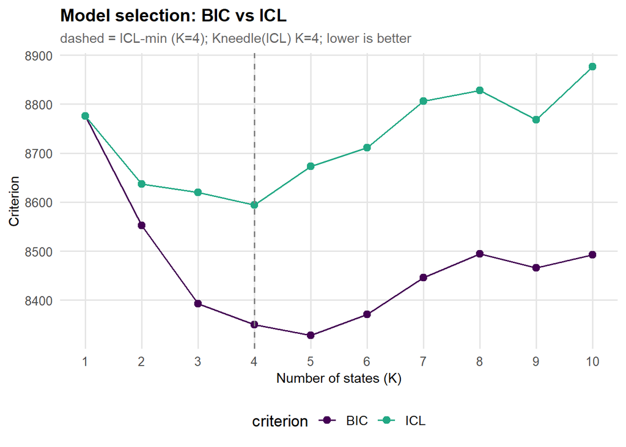

```r
#2.2 BIC vs ICL: ICL adds an overlap/entropy penalty, so it resists the
#    over-splitting BIC shows when the mixture tiles density rather than finding
#    distinct subgroups
crit_long <- sel$bic_table |>
  dplyr::select(K, BIC = bic, ICL = icl) |>
  tidyr::pivot_longer(c(BIC, ICL), names_to = "criterion", values_to = "value")

ggplot(crit_long, aes(K, value, colour = criterion)) +
  geom_line(linewidth = 0.7) +
  geom_point(size = 2.4) +
  geom_vline(xintercept = sel$best_k_icl, linetype = 2, colour = "grey50") +
  scale_colour_viridis_d(end = 0.6) +
  scale_x_continuous(breaks = sel$bic_table$K) +
  labs(title = "Model selection: BIC vs ICL",
       subtitle = glue::glue("dashed = ICL-min (K={sel$best_k_icl}); ",
                             "Kneedle(ICL) K={k_knee_icl}; lower is better"),
       x = "Number of states (K)", y = "Criterion") +
  theme_hw()
```

```r
#2.3 Candidate K set for the density comparison (DYNAMIC; config-overridable).
#    Defaults to the ICL minimum, the ICL knee, and K=2 if not specified given
#    K=2 relevance derived from viewing the density plots
candidate_k <- if (!is.null(cfg$gmm$candidate_k)) {
  sort(unique(unlist(cfg$gmm$candidate_k)))
} else {
  sort(unique(c(2L, sel$best_k_icl, k_knee_icl)))
}
```

[output not shown]

```r
## 2.4b K-means baseline + distance-based validation (WSS elbow, silhouette) ##

# WHY: k-means is the hard-assignment, spherical-equal-covariance special case of
# a GMM, so it is a good baseline and shows what the Gaussian architecture
# (soft assignments + full per-state covariance) actually buys. Its standard
# validity indices are DISTANCE-based (WSS elbow, silhouette), an objective
# entirely independent of the likelihood-based BIC/ICL/CV used for the GMM. If
# the distance view also favours a small K near 4, that is convergent evidence
# from a different criterion; if not, it is a robustness caveat
km_k <- 2:10
set.seed(cfg$gmm$seed)

#2.4b.1 Fit k-means at each K with many restarts via nstart for stable WSS
km_fits <- lapply(km_k, function(k)
  stats::kmeans(X, centers = k, nstart = 25, iter.max = 100))
names(km_fits) <- km_k

#2.4b.2 Average silhouette width FROM SCRATCH (no cluster/factoextra dependency).
#       s(i) = (b_i - a_i) / max(a_i, b_i): a_i = mean dist to own-cluster points,
#       b_i = min over other clusters of mean dist to that cluster. Computed on a
#       capped random subsample for an O(m^2) distance matrix
avg_silhouette <- function(Xmat, cl) {
  n <- nrow(Xmat)
  D <- as.matrix(stats::dist(Xmat))
  ks <- sort(unique(cl))
  sil <- numeric(n)
  for (i in seq_len(n)) {
    own <- cl == cl[i]; own[i] <- FALSE
    a_i <- if (any(own)) mean(D[i, own]) else 0
    b_i <- min(vapply(setdiff(ks, cl[i]), function(g) mean(D[i, cl == g]), numeric(1)))
    sil[i] <- if (max(a_i, b_i) > 0) (b_i - a_i) / max(a_i, b_i) else 0
  }
  mean(sil)
}

#2.4b.3 Subsample cap for the silhouette distance matrix
m_cap <- min(nrow(X), 600L)
sil_idx <- sample(seq_len(nrow(X)), m_cap)

km_val <- tibble::tibble(
  K = km_k,
  wss = vapply(km_fits, function(f) f$tot.withinss, numeric(1)),
  silhouette = vapply(km_k, function(k)
    avg_silhouette(X[sil_idx, , drop = FALSE], km_fits[[as.character(k)]]$cluster[sil_idx]),
    numeric(1)))

km_sil_best <- km_val$K[which.max(km_val$silhouette)]
message(glue::glue("K-means: peak average silhouette at K={km_sil_best} ",
                   "(GMM chosen K={chosen_k}). WSS elbow read from the curve below."))
```

```
K-means: peak average silhouette at K=2 (GMM chosen K=4). WSS elbow read from the curve below.
```

```r
nice_tbl(km_val, digits = c(0, 1, 3),
         caption = "K-means validation: within-cluster SS (elbow) and average silhouette width")
```

K-means validation: within-cluster SS (elbow) and average silhouette width

| K | wss | silhouette |
| --- | --- | --- |
| 2 | 2462.6 | 0.242 |
| 3 | 2092.1 | 0.222 |
| 4 | 1837.2 | 0.229 |
| 5 | 1606.8 | 0.216 |
| 6 | 1455.0 | 0.206 |
| 7 | 1344.3 | 0.199 |
| 8 | 1243.9 | 0.216 |
| 9 | 1174.2 | 0.216 |
| 10 | 1115.3 | 0.212 |

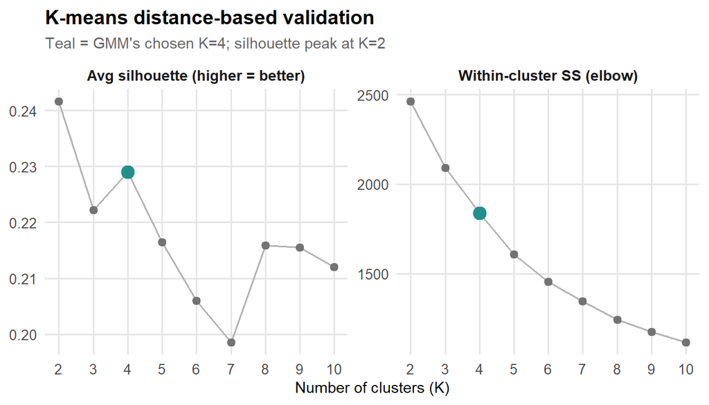

```r
#2.4b.4 Twin curves: WSS (lower, look for the elbow) and silhouette (higher = more
#       separated, distinct clusters)
km_long <- km_val |>
  tidyr::pivot_longer(c(wss, silhouette), names_to = "metric", values_to = "value") |>
  dplyr::mutate(metric = dplyr::recode(metric,
                  wss = "Within-cluster SS (elbow)",
                  silhouette = "Avg silhouette (higher = better)"))

ggplot(km_long, aes(K, value)) +
  geom_line(colour = "grey70", linewidth = 0.6) +
  geom_point(size = 2.3, colour = "grey45") +
  geom_point(data = dplyr::filter(km_long, K == chosen_k), size = 4, colour = "#21908C") +
  facet_wrap(~ metric, scales = "free_y") +
  scale_x_continuous(breaks = km_k) +
  labs(title = "K-means distance-based validation",
       subtitle = glue::glue("Teal = GMM's chosen K={chosen_k}; ",
                             "silhouette peak at K={km_sil_best}"),
       x = "Number of clusters (K)", y = NULL) +
  theme_hw()
```

```r
#2.4b.5 Concordance with the GMM partition at the chosen K (adjusted Rand index):
#       do the soft Gaussian states and the hard k-means clusters largely agree?
adjusted_rand_km <- function(a, b) {
  tab <- table(a, b); cc <- function(x) choose(x, 2)
  sij <- sum(cc(tab)); si <- sum(cc(rowSums(tab))); sj <- sum(cc(colSums(tab)))
  expected <- si * sj / cc(sum(tab)); maxidx <- (si + sj) / 2
  (sij - expected) / (maxidx - expected)
}
ari_km_gmm <- adjusted_rand_km(gmm_map_assign(best),
                               km_fits[[as.character(chosen_k)]]$cluster)
message(glue::glue("GMM vs k-means agreement at K={chosen_k}: adjusted Rand index = ",
                   "{round(ari_km_gmm, 3)} (1 = identical partitions)."))
```

```
GMM vs k-means agreement at K=4: adjusted Rand index = 0.326 (1 = identical partitions).
```

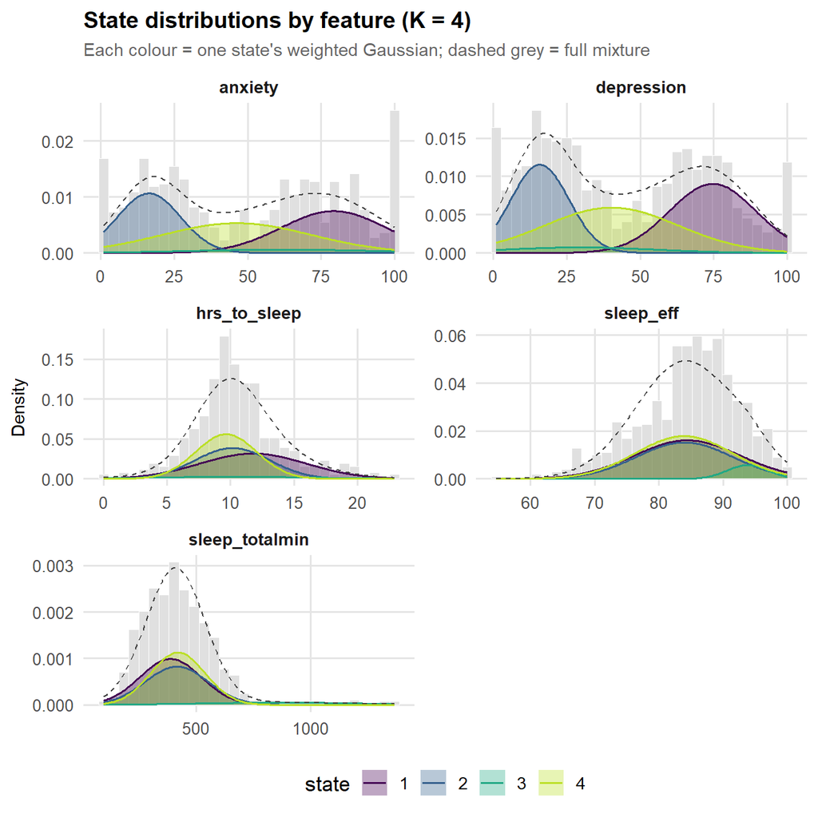

```r
## 2.4 What each state's distribution looks like (at the chosen K) ##

#2.4.1 PLOT A: per-feature component densities, one curve PER STATE, over the
#      data histogram. Reads as: "for this feature, here is each state's density
#      and where it sits."
comp_dens <- purrr::map_dfr(colnames(X),
  function(f) gmm_component_density(best, X, f))

mix_dens  <- purrr::map_dfr(colnames(X),
  function(f) gmm_marginal_density(best, X, f))

model_long <- model_df |>
  dplyr::select(dplyr::all_of(colnames(X))) |>
  tidyr::pivot_longer(dplyr::everything(), names_to = "feature", values_to = "value")

ggplot() +
  geom_histogram(data = model_long, aes(value, y = ggplot2::after_stat(density)),
                 bins = 30, fill = "grey88", colour = "white", linewidth = 0.2) +
  geom_area(data = comp_dens, aes(value, density, fill = state),
            position = "identity", alpha = 0.35) +
  geom_line(data = comp_dens, aes(value, density, colour = state), linewidth = 0.7) +
  geom_line(data = mix_dens, aes(value, density), colour = "grey25",
            linetype = 2, linewidth = 0.5) +
  facet_wrap(~ feature, scales = "free", ncol = 2) +
  scale_fill_viridis_d(end = 0.9) + scale_colour_viridis_d(end = 0.9) +
  labs(title = glue::glue("State distributions by feature (K = {best$K})"),
       subtitle = "Each colour = one state's weighted Gaussian; dashed grey = full mixture",
       x = NULL, y = "Density") +
  theme_hw()
```

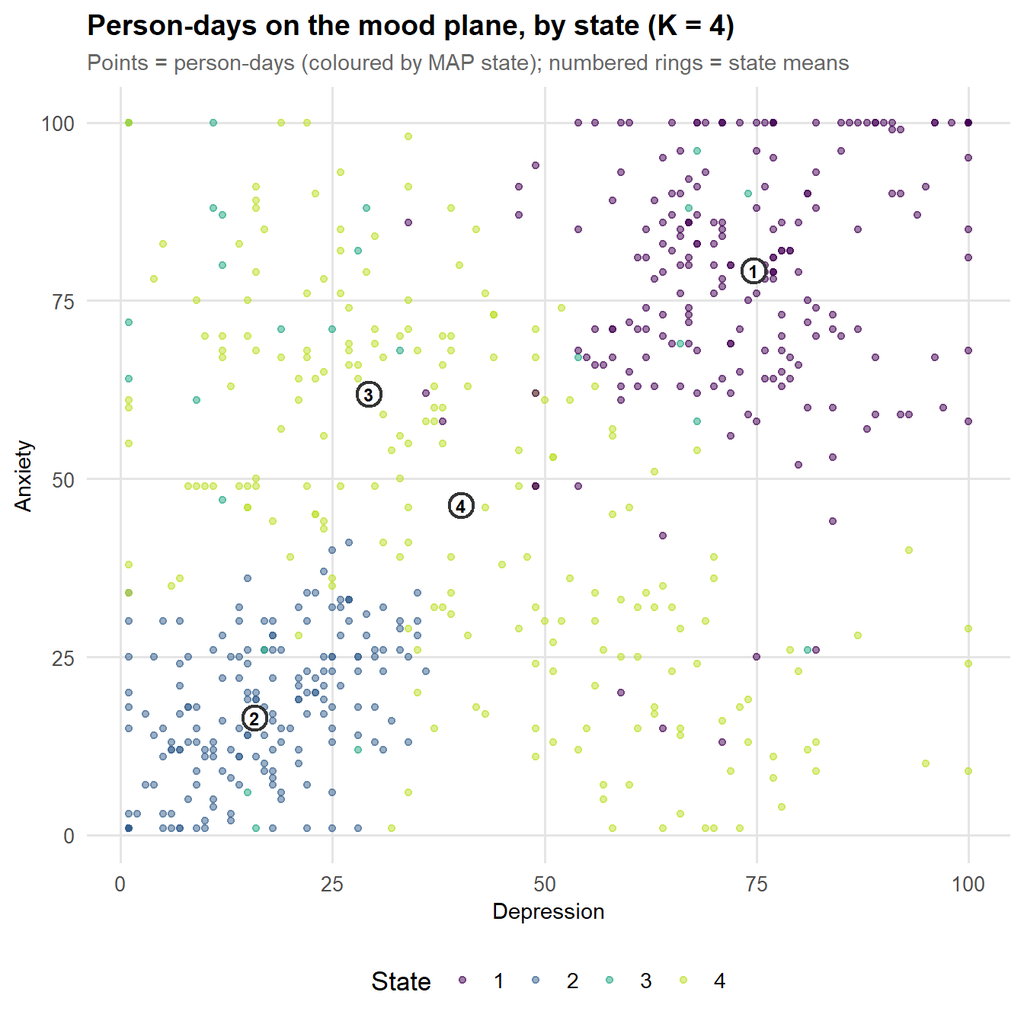

```r
#2.4.2 PLOT B: the mood plane, coloured by hard state assignment, with each
#      state's mean marked. Depression x anxiety = the dominant axis
if (all(c("depression", "anxiety") %in% colnames(X))) {
  state_means <- gmm_state_profile(best, X)

  ggplot(model_df, aes(depression, anxiety)) +
    geom_point(aes(colour = factor(gmm_map_assign(best))), alpha = 0.5, size = 1.4) +
    geom_point(data = state_means, aes(depression, anxiety),
               shape = 21, size = 5, stroke = 1.1, fill = "white", colour = "grey20") +
    geom_text(data = state_means, aes(depression, anxiety, label = state),
              size = 3.2, fontface = "bold") +
    scale_colour_viridis_d(end = 0.9, name = "State") +
    labs(title = glue::glue("Person-days on the mood plane, by state (K = {best$K})"),
         subtitle = "Points = person-days (coloured by MAP state); numbered rings = state means",
         x = "Depression", y = "Anxiety") +
    theme_hw()
}
```

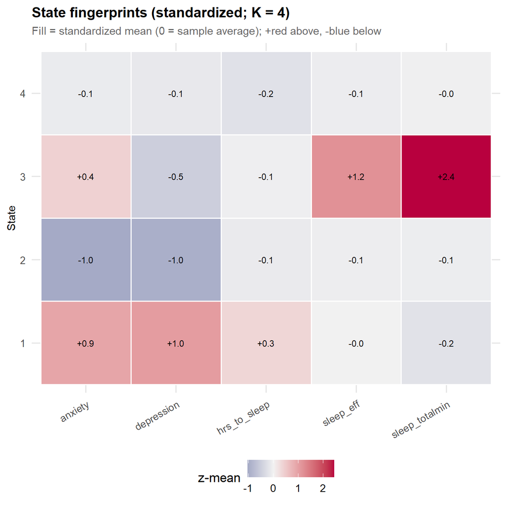

```r
#2.4.3 PLOT C: standardized state x feature heatmap (compact fingerprint).
#      A single grid: rows = states, columns = features, fill = z-mean. Fast read
#      of "what is high/low in each state" across ALL features at once
fing_long <- best$mu |>
  `colnames<-`(colnames(X)) |>
  tibble::as_tibble() |>
  dplyr::mutate(state = factor(seq_len(best$K))) |>
  tidyr::pivot_longer(-state, names_to = "feature", values_to = "z_mean")

ggplot(fing_long, aes(feature, state, fill = z_mean)) +
  geom_tile(colour = "white", linewidth = 0.6) +
  geom_text(aes(label = sprintf("%+.1f", z_mean)), size = 3) +
  scale_fill_gradient2(low = "#3B528B", mid = "grey95", high = "#B8003E",
                       midpoint = 0, name = "z-mean") +
  labs(title = glue::glue("State fingerprints (standardized; K = {best$K})"),
       subtitle = "Fill = standardized mean (0 = sample average); +red above, -blue below",
       x = NULL, y = "State") +
  theme_hw() + theme(axis.text.x = element_text(angle = 30, hjust = 1))
```

```r
## 2.6 What ARE the states? Native-unit profiles + standardized fingerprints ##

nice_tbl(gmm_state_profile(best, X), digits = 2,
         caption = "Latent state profiles (native units) and state size")
```

Latent state profiles (native units) and state size

| state | weight | n_days | depression | anxiety | sleep_eff | hrs_to_sleep | sleep_totalmin |
| --- | --- | --- | --- | --- | --- | --- | --- |
| 1 | 0.33 | 216 | 74.68 | 79.24 | 84.41 | 11.77 | 388.34 |
| 2 | 0.28 | 193 | 15.86 | 16.48 | 83.98 | 10.15 | 414.90 |
| 3 | 0.05 | 26 | 29.30 | 61.95 | 93.81 | 10.33 | 862.12 |
| 4 | 0.34 | 209 | 40.20 | 46.26 | 83.92 | 9.67 | 420.42 |

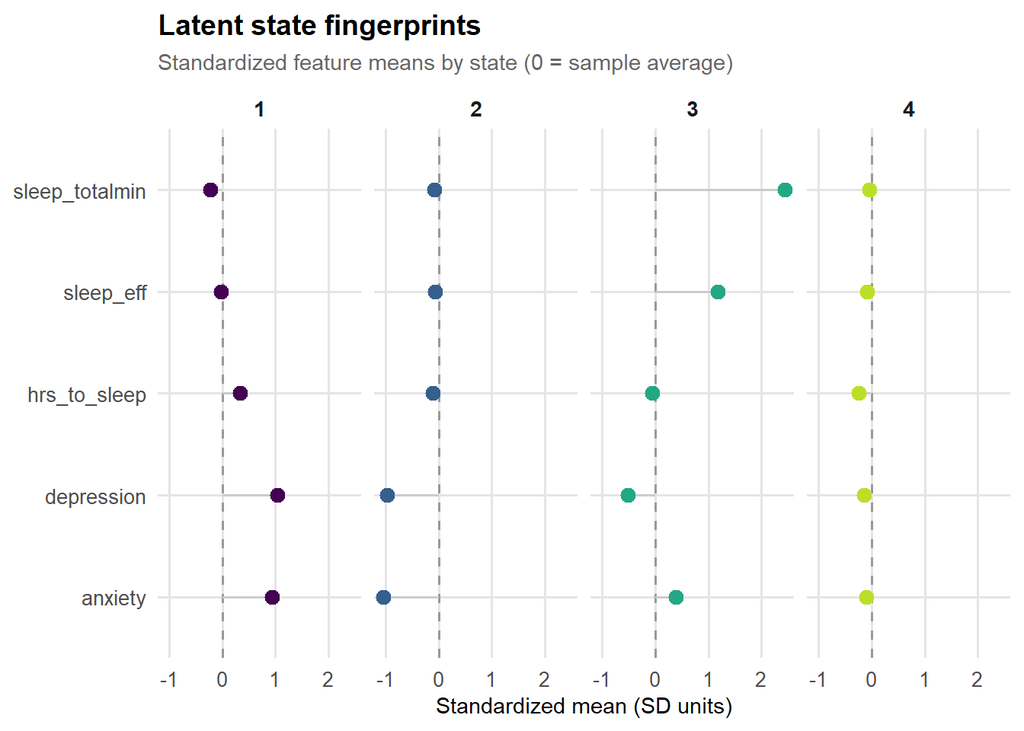

```r
#2.6.1 Standardized fingerprint (z-units; 0 = sample average), lollipop per state
fing <- best$mu

colnames(fing) <- colnames(X)

fing <- tibble::as_tibble(fing)

fing$state <- factor(seq_len(best$K))

fing_long <- tidyr::pivot_longer(fing, -state, names_to = "feature", values_to = "z_mean")

ggplot(fing_long, aes(x = z_mean, y = feature, colour = state)) +
  geom_vline(xintercept = 0, linetype = 2, colour = "grey60") +
  geom_segment(aes(x = 0, xend = z_mean, yend = feature), colour = "grey80", linewidth = 0.6) +
  geom_point(size = 3) +
  facet_wrap(~ state, nrow = 1) +
  scale_colour_viridis_d(end = 0.9) +
  labs(title = "Latent state fingerprints",
       subtitle = "Standardized feature means by state (0 = sample average)",
       x = "Standardized mean (SD units)", y = NULL) +
  theme_hw() + theme(legend.position = "none")
```

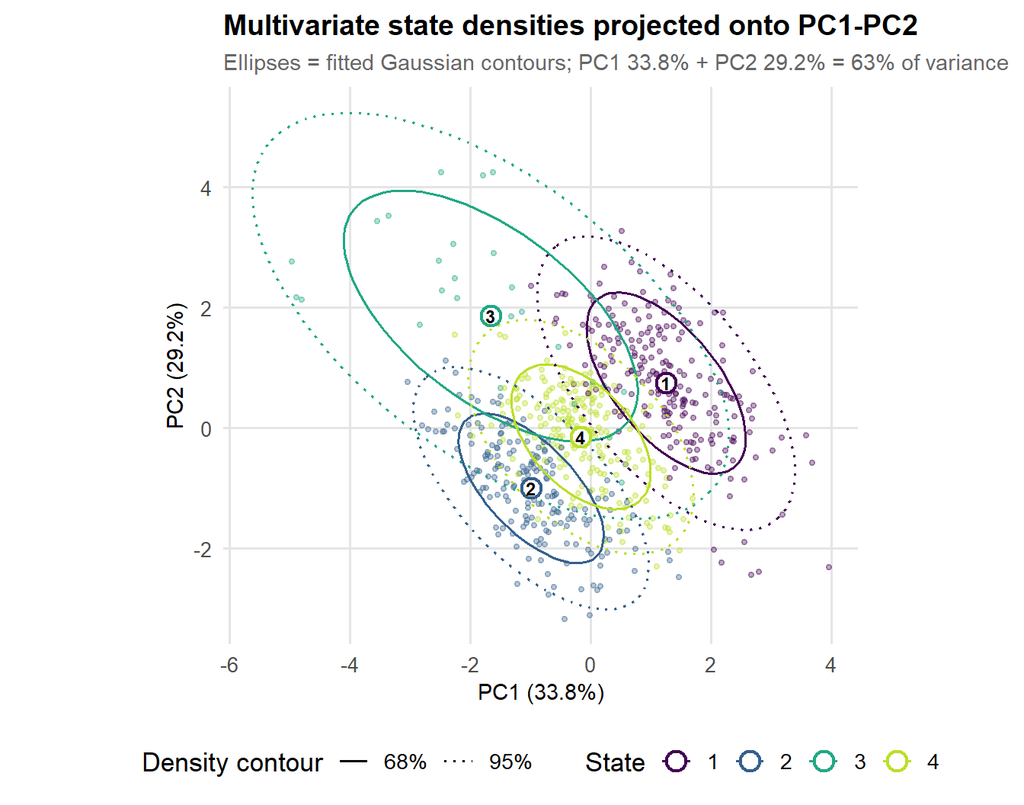

```r
## 2.6b Multivariate state densities, projected to 2-D via PCA ##

# The states are 5-D Gaussians; to SEE them as overlapping multivariate
# densities we project to 2-D. PCA is the faithful choice: it is a LINEAR
# projection, so each fitted component's mean and covariance map exactly onto the
# plane (mu -> V'mu, Sigma -> V'Sigma V, V = top-2 loadings). We are NOT
# refitting in 2-D, just viewing the 5-D fit from a different angle

#2.6b.1 PCA on the standardized modeling matrix the GMM was fit on
pca <- stats::prcomp(X, center = FALSE, scale. = FALSE)
V <- pca$rotation[, 1:2]
var_pc <- round(100 * (pca$sdev^2 / sum(pca$sdev^2))[1:2], 1)

#2.6b.2 Project data + each component's mean and covariance onto the plane
scores <- as.data.frame(X %*% V); colnames(scores) <- c("PC1", "PC2")
scores$state <- factor(gmm_map_assign(best))
mu_proj <- best$mu %*% V
Sig_proj <- lapply(best$Sigma, function(S) t(V) %*% S %*% V)

#2.6b.3 Covariance ellipse FROM SCRATCH: eigen-decompose the projected 2x2
#       covariance; axis half-lengths = sqrt(eigenvalue) * sqrt(qchisq(level, 2))
#       oriented by the eigenvectors. This contour encloses `level` of that
#       Gaussian's mass
ellipse_pts <- function(mu2, S2, level = 0.68, n = 80) {
  eg <- eigen(S2, symmetric = TRUE)
  rad <- sqrt(stats::qchisq(level, df = 2))
  theta <- seq(0, 2 * pi, length.out = n)
  pts <- eg$vectors %*% diag(rad * sqrt(pmax(eg$values, 0))) %*% rbind(cos(theta), sin(theta))
  data.frame(PC1 = mu2[1] + pts[1, ], PC2 = mu2[2] + pts[2, ])
}

ell_df <- purrr::map_dfr(seq_len(best$K), function(k) {
  dplyr::bind_rows(
    dplyr::mutate(ellipse_pts(mu_proj[k, ], Sig_proj[[k]], 0.68), level = "68%"),
    dplyr::mutate(ellipse_pts(mu_proj[k, ], Sig_proj[[k]], 0.95), level = "95%")) |>
    dplyr::mutate(state = factor(k))
})
cent_df <- data.frame(PC1 = mu_proj[, 1], PC2 = mu_proj[, 2], state = factor(seq_len(best$K)))

#2.6b.4 Scatter (MAP-coloured) + 68%/95% density ellipses + labelled centroids.
#       Ellipse overlap = density overlap in-plane; size/tilt = each states
#       spread and feature covariance
ggplot(scores, aes(PC1, PC2, colour = state)) +
  geom_point(alpha = 0.35, size = 1.1) +
  geom_path(data = ell_df, aes(group = interaction(state, level), linetype = level),
            linewidth = 0.7) +
  geom_point(data = cent_df, size = 4, shape = 21, fill = "white", stroke = 1.1) +
  geom_text(data = cent_df, aes(label = state), colour = "black",
            fontface = "bold", size = 3.2) +
  scale_colour_viridis_d(end = 0.9, name = "State") +
  scale_linetype_manual(values = c("68%" = 1, "95%" = 3), name = "Density contour") +
  coord_equal() +
  labs(title = "Multivariate state densities projected onto PC1-PC2",
       subtitle = glue::glue("Ellipses = fitted Gaussian contours; PC1 {var_pc[1]}% + ",
                             "PC2 {var_pc[2]}% = {round(sum(var_pc), 1)}% of variance"),
       x = glue::glue("PC1 ({var_pc[1]}%)"), y = glue::glue("PC2 ({var_pc[2]}%)")) +
  theme_hw()
```

```r
#2.6b.5 PC loadings: which features define the projection plane
nice_tbl(
  tibble::as_tibble(round(pca$rotation[, 1:2], 2), rownames = "feature"),
  caption = glue::glue("PC1/PC2 loadings (PC1 = {var_pc[1]}%, PC2 = {var_pc[2]}% ",
                       "of variance): how features define the projection plane"))
```

PC1/PC2 loadings (PC1 = 33.8%, PC2 = 29.2% of variance): how features define the projection plane

| feature | PC1 | PC2 |
| --- | --- | --- |
| depression | 0.53 | 0.43 |
| anxiety | 0.48 | 0.50 |
| sleep_eff | -0.33 | 0.54 |
| hrs_to_sleep | 0.38 | -0.12 |
| sleep_totalmin | -0.48 | 0.51 |

```r
## 2.7 Person x state check: is any state just one person's days? ##
chk <- gmm_person_state_check(best, person_id)

nice_tbl(data.frame(state = seq_along(chk$max_person_share),
                    n_days = as.integer(chk$state_totals),
                    max_single_person_share = round(chk$max_person_share, 3)),
         caption = "Per-state size and single-person dominance (high share => trait artifact)")
```

Per-state size and single-person dominance (high share => trait artifact)

| state | n_days | max_single_person_share |
| --- | --- | --- |
| 1 | 216 | 0.106 |
| 2 | 193 | 0.114 |
| 3 | 26 | 0.154 |
| 4 | 209 | 0.091 |

## 2.8 Sensitivity: within-person (person-mean-centered) refit

The primary model is fit on raw (i.e., across-sample standardized) person-days, so a fair objection is that the states might be sorting people (e.g., chronically high-distress vs chronically euthymic individuals) rather than capturing within-person day-to-day shifts; the latter being the dynamical-systems claim we actually are interested in. The artifact check already shows no state is one person’s days, & this sensitivity goes further by asking whether the same state structure survives when all stable between-person differences are removed

Two reads. First, the per-feature **ICC(1)** quantifies how much of each feature’s variance is between-person (trait) vs within-person (state). The lower the ICC, the more a feature reflects legit day-to-day movement, and the more defensible the uncentered model is as the primary. Second, we refit the entire GMM on person-mean-centered features, with each day expressed relative to that person’s own average, and ask whether (a) model selection still prefers a comparable K, (b) the centered states show the same qualitative fingerprints, and (c) the day-level assignments agree with the primary solution (adjusted Rand index). We do not expect identical partitions bc centering deliberately moves a chronically-depressed person’s average day off the high-distress state, so the scientific question is whether a recognizable distress/euthymic structure re-emerges from purely within-person variation

```r
## 2.8.1 Per-feature ICC(1): between-person (trait) vs within-person (state) ##

#2.8.1 One-way random-effects ICC via base-R aov (no new dependencies). High ICC
#      => the feature mostly separates people (trait-like); low ICC => it mostly
#      tracks within-person change (state-like, the signal we want). k0 is the
#      unbalanced-design average group size
icc1 <- function(value, group) {
  group <- factor(group)
  ni <- table(group); g <- length(ni); N <- length(value)
  ms <- summary(stats::aov(value ~ group))[[1]][, "Mean Sq"]
  msb <- ms[1]; msw <- ms[2]
  k0 <- (N - sum(ni^2) / N) / (g - 1)
  max((msb - msw) / (msb + (k0 - 1) * msw), 0)         # floor at 0
}

icc_tbl <- tibble::tibble(
  feature = feat_model,
  icc = vapply(feat_model, function(f) icc1(model_df[[f]], person_id), numeric(1))) |>
  dplyr::mutate(pct_within = round(100 * (1 - icc), 1), icc = round(icc, 3)) |>
  dplyr::arrange(icc)

nice_tbl(icc_tbl,
         caption = "Per-feature ICC(1): trait (between) vs state (within) variance share")
```

Per-feature ICC(1): trait (between) vs state (within) variance share

| feature | icc | pct_within |
| --- | --- | --- |
| sleep_totalmin | 0.140 | 86.0 |
| hrs_to_sleep | 0.161 | 83.9 |
| sleep_eff | 0.249 | 75.1 |
| anxiety | 0.355 | 64.5 |
| depression | 0.387 | 61.3 |

```r
## 2.8.2 Refit the GMM on person-mean-centered (within-person) features ##

#2.8.2.1 Strip each person's own mean from every modeling feature, then
#        re-standardize so the centered matrix carries the center/scale
#        attributes the profilers need. Centered features encode "this day vs
#        this person's average," removing all stable between-person differences
Xc <- zscore_matrix(person_center(model_df[, feat_model], person_id))

#2.8.2.2 Run the SAME selection machinery on the centered data: does centering
#        change the preferred K?
sel_c <- gmm_select_k(
  Xc, k_range = unlist(cfg$gmm$k_range), n_restarts = cfg$gmm$n_restarts,
  max_iter = cfg$gmm$max_iter, tol = cfg$gmm$tol, ridge = cfg$gmm$ridge,
  seed = cfg$gmm$seed)

k_knee_bic_c <- kneedle(sel_c$bic_table$K, sel_c$bic_table$bic)
k_knee_icl_c <- kneedle(sel_c$bic_table$K, sel_c$bic_table$icl)
message(glue::glue(
  "CENTERED selection: BIC min K={sel_c$best_k} | ICL min K={sel_c$best_k_icl} | ",
  "Kneedle(BIC) K={k_knee_bic_c} | Kneedle(ICL) K={k_knee_icl_c}"))
```

```
CENTERED selection: BIC min K=3 | ICL min K=2 | Kneedle(BIC) K=4 | Kneedle(ICL) K=2
```

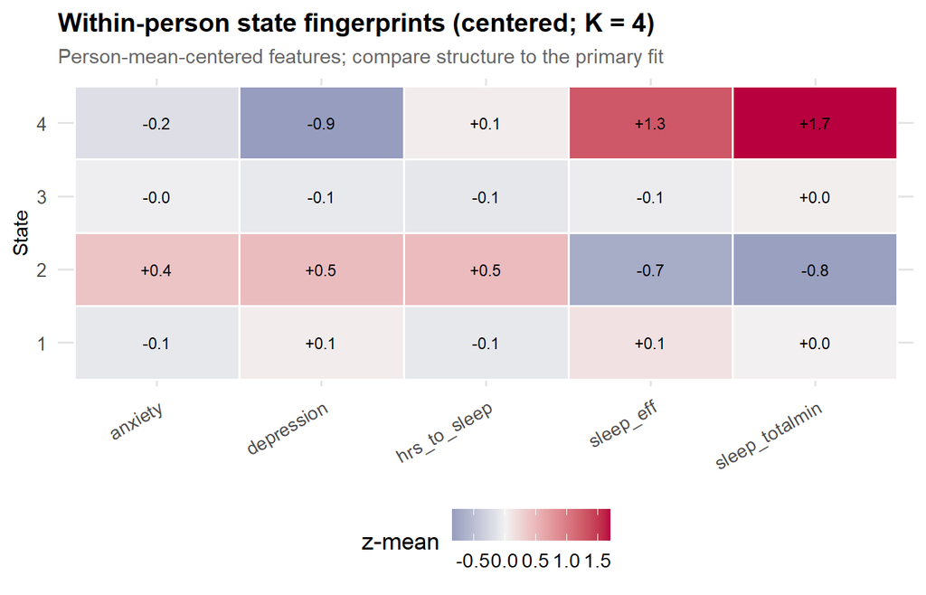

```r
#2.8.2.3 Hold K at the PRIMARY chosen_k so the two partitions are directly
#        comparable, then read the centered states' standardized fingerprints
best_c <- sel_c$fits[[as.character(chosen_k)]]

fing_c <- best_c$mu
colnames(fing_c) <- colnames(Xc)
fing_c <- tibble::as_tibble(fing_c)
fing_c$state <- factor(seq_len(best_c$K))
fing_c_long <- tidyr::pivot_longer(fing_c, -state, names_to = "feature", values_to = "z_mean")

ggplot(fing_c_long, aes(feature, state, fill = z_mean)) +
  geom_tile(colour = "white", linewidth = 0.6) +
  geom_text(aes(label = sprintf("%+.1f", z_mean)), size = 3) +
  scale_fill_gradient2(low = "#3B528B", mid = "grey95", high = "#B8003E",
                       midpoint = 0, name = "z-mean") +
  labs(title = glue::glue("Within-person state fingerprints (centered; K = {best_c$K})"),
       subtitle = "Person-mean-centered features; compare structure to the primary fit",
       x = NULL, y = "State") +
  theme_hw() + theme(axis.text.x = element_text(angle = 30, hjust = 1))
```

```r
## 2.8.3 Do the two solutions agree? Confusion matrix + adjusted Rand index ##

#2.8.3.1 Adjusted Rand index from scratch: partition agreement corrected for
#        chance (0 = chance, 1 = identical). Invariant to label permutation, so
#        it sidesteps GMM label-switching between the two fits
adjusted_rand <- function(a, b) {
  tab <- table(a, b); cc <- function(x) choose(x, 2)
  sij <- sum(cc(tab)); si <- sum(cc(rowSums(tab))); sj <- sum(cc(colSums(tab)))
  expected <- si * sj / cc(sum(tab)); maxidx <- (si + sj) / 2
  (sij - expected) / (maxidx - expected)
}

state_primary <- gmm_map_assign(best)
state_centered <- gmm_map_assign(best_c)
ari <- adjusted_rand(state_primary, state_centered)

#2.8.3.2 Confusion matrix: rows = primary (uncentered) state, cols = centered
xtab <- as.data.frame.matrix(table(primary = state_primary, centered = state_centered))
xtab <- tibble::rownames_to_column(xtab, "primary \\ centered")
nice_tbl(xtab, digits = 0,
         caption = glue::glue("Primary x centered assignment (adjusted Rand index = {round(ari, 3)})"))
```

Primary x centered assignment (adjusted Rand index = 0.144)

| primary centered | 1 | 2 | 3 | 4 |
| --- | --- | --- | --- | --- |
| 1 | 108 | 70 | 33 | 5 |
| 2 | 118 | 11 | 59 | 5 |
| 3 | 1 | 0 | 2 | 23 |
| 4 | 60 | 6 | 137 | 6 |

```r
#2.8.3.3 Does the high-SI gradient survive centering? SI overlay by CENTERED state
model_df$state_centered <- factor(state_centered)
overlay_vars_c <- intersect(c(cfg$overlay$primary, cfg$overlay$secondary, cfg$overlay$rare),
                            names(model_df))
nice_tbl(
  model_df |>
    dplyr::group_by(state_centered) |>
    dplyr::summarise(n_days = dplyr::n(),
                     dplyr::across(dplyr::all_of(overlay_vars_c), ~ mean(.x, na.rm = TRUE)),
                     .groups = "drop"),
  digits = 3, caption = "SI/SB profile by within-person (centered) state")
```

SI/SB profile by within-person (centered) state

| state_centered | n_days | si_any | si_severity | si_bother | commission | ACTIVESIWITHINTENT | SELFHARM | SUICIDEATTEMPT |
| --- | --- | --- | --- | --- | --- | --- | --- | --- |
| 1 | 287 | 0.337 | 0.498 | 24.487 | 0.022 | 1.052 | 0.018 | 0.000 |
| 2 | 87 | 0.517 | 0.851 | 38.966 | 0.026 | 1.089 | 0.000 | 0.000 |
| 3 | 231 | 0.248 | 0.335 | 18.863 | 0.020 | 1.018 | 0.004 | 0.004 |
| 4 | 39 | 0.385 | 0.538 | 24.795 | 0.021 | 1.000 | 0.026 | 0.000 |

## 2.9 EM verification & density-estimation adequacy

The mixture is hand-implemented, so before any scientific claim we need to verify the algorithm and the density estimate separately. Four checks, each targeting a distinct potential point of failure:

1. **EM monotonicity**: EM never decreases the observed-data log-likelihood; a single decrease in the iteration trace means the implementation is wrong
2. **Restart stability**: EM only finds local optima. If the 50 restarts scatter across many distinct log-likelihood values, the reported solution is initialization luck; if most restarts reach the same best mode, the optimum is reliable
3. **Posterior predictive check (PPC)**: a good density estimate must be able to regenerate the data. We thus simulate person-days from the fitted mixture and compare simulated vs observed marginals and the full correlation structure. PIT values, AKA the fitted marginal CDF evaluated at each observation, should be approximately Uniform(0,1) if the marginals fit.
4. **Person-blocked cross-validated log-likelihood**: a direct, assumption- free answer to “BIC’s penalty assumes independent rows.” Held-out density makes no effective-N assumption and if K = 4 generalizes to unseen people, its held-out log-likelihood should be competitive, and overfit K should drop

```r
## 2.9.1 EM correctness: monotone log-likelihood + restart stability ##

#2.9.1.1 Monotonicity audit on the chosen fit's iteration trace. Tolerance 1e-8
#        absorbs floating-point noise only
ll_tr <- best$log_lik_trace
mono_viol <- sum(diff(ll_tr) < -1e-8)
message(glue::glue(
  "EM monotonicity: {length(ll_tr)} iterations, {mono_viol} decreases ",
  "(must be 0); total log-lik climb = {round(ll_tr[length(ll_tr)] - ll_tr[1], 1)}."))
```

```
EM monotonicity: 326 iterations, 0 decreases (must be 0); total log-lik climb = 1357.9.
```

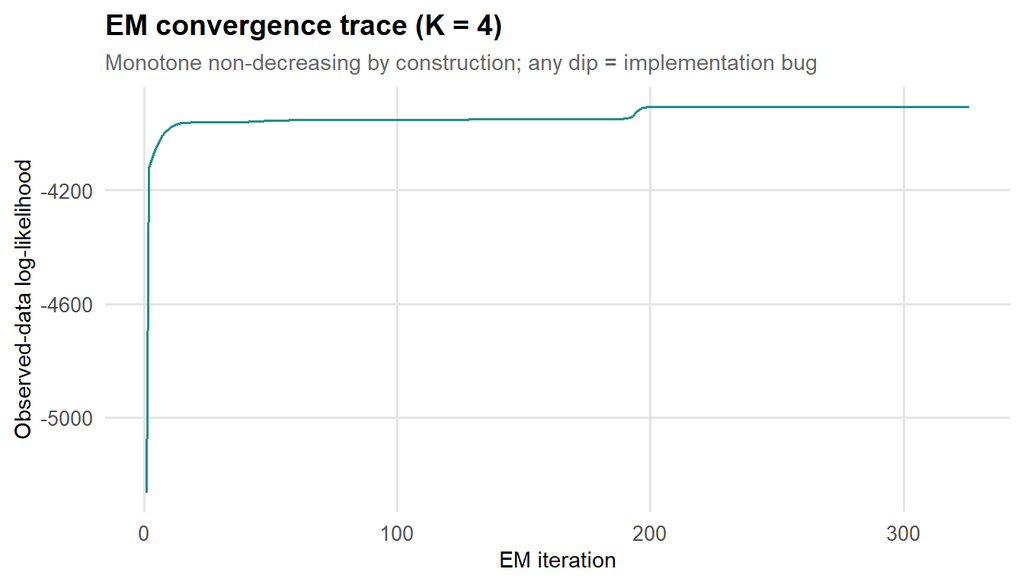

```r
ggplot(data.frame(iter = seq_along(ll_tr), loglik = ll_tr), aes(iter, loglik)) +
  geom_line(colour = "#21908C", linewidth = 0.7) +
  labs(title = glue::glue("EM convergence trace (K = {best$K})"),
       subtitle = "Monotone non-decreasing by construction; any dip = implementation bug",
       x = "EM iteration", y = "Observed-data log-likelihood") +
  theme_hw()
```

```r
#2.9.1.2 Restart stability: final log-lik of every restart at the chosen K.
#        "Modal share" = fraction of restarts landing within 1e-3 of the best
rl <- best$restart_loglik[is.finite(best$restart_loglik)]
modal_share <- mean(rl > max(rl) - 1e-3)
message(glue::glue(
  "Restart stability: {length(rl)} restarts, {round(100 * modal_share, 1)}% ",
  "reached the best mode (spread = {round(max(rl) - min(rl), 1)} log-lik units)."))
```

```
Restart stability: 50 restarts, 2% reached the best mode (spread = 109.1 log-lik units).
```

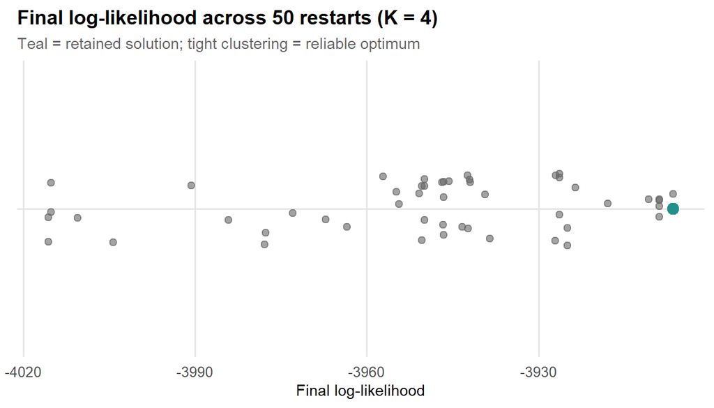

```r
ggplot(data.frame(loglik = rl), aes(x = loglik, y = "")) +
  geom_jitter(height = 0.15, size = 2, alpha = 0.6, colour = "grey40") +
  geom_point(aes(x = max(rl), y = ""), colour = "#21908C", size = 3.5) +
  labs(title = glue::glue("Final log-likelihood across {length(rl)} restarts (K = {best$K})"),
       subtitle = "Teal = retained solution; tight clustering = reliable optimum",
       x = "Final log-likelihood", y = NULL) +
  theme_hw()
```

[figure not shown]

```r
## 2.9.2 Posterior predictive check: can the fitted mixture regenerate the data? ##

#2.9.2.1 Simulate as many person-days as observed, de-standardize to native units
sim <- gmm_simulate(best, n = nrow(X), seed = cfg$gmm$seed)
sim_native <- sweep(sweep(sim$X, 2L, attr(X, "scale"), "*"), 2L, attr(X, "center"), "+")

ppc_long <- dplyr::bind_rows(
  model_df |> dplyr::select(dplyr::all_of(colnames(X))) |>
    tidyr::pivot_longer(dplyr::everything(), names_to = "feature", values_to = "value") |>
    dplyr::mutate(source = "observed"),
  tibble::as_tibble(sim_native) |>
    tidyr::pivot_longer(dplyr::everything(), names_to = "feature", values_to = "value") |>
    dplyr::mutate(source = "simulated"))

#2.9.2.2 Overlay: simulated density should trace the observed histogram. Misfit
#        shows as systematic gaps (e.g., unmodeled skew or floors)
ggplot() +
  geom_histogram(data = dplyr::filter(ppc_long, source == "observed"),
                 aes(value, y = ggplot2::after_stat(density)),
                 bins = 30, fill = "grey85", colour = "white", linewidth = 0.2) +
  geom_density(data = dplyr::filter(ppc_long, source == "simulated"),
               aes(value), colour = "#21908C", linewidth = 0.8) +
  facet_wrap(~ feature, scales = "free", ncol = 2) +
  labs(title = glue::glue("Posterior predictive check (K = {best$K})"),
       subtitle = "Grey = observed person-days; teal = density of mixture-simulated person-days",
       x = NULL, y = "Density") +
  theme_hw()
```

```r
#2.9.2.3 Joint structure: the simulated CORRELATION matrix must match the
#        observed one Report the worst absolute discrepancy across all
#        feature pairs
cor_obs <- stats::cor(X)
cor_sim <- stats::cor(sim$X)
cor_diff <- cor_sim - cor_obs

message(glue::glue(
  "PPC correlation recovery: max |simulated - observed| correlation = ",
  "{round(max(abs(cor_diff[upper.tri(cor_diff)])), 3)} across ",
  "{sum(upper.tri(cor_diff))} feature pairs."))
```

```
PPC correlation recovery: max |simulated - observed| correlation = 0.051 across 10 feature pairs.
```

[figure not shown]

```r
cor_long <- dplyr::bind_rows(
  tibble::as_tibble(cor_obs, rownames = "f1") |>
    tidyr::pivot_longer(-f1, names_to = "f2", values_to = "r") |>
    dplyr::mutate(source = "observed"),
  tibble::as_tibble(cor_sim, rownames = "f1") |>
    tidyr::pivot_longer(-f1, names_to = "f2", values_to = "r") |>
    dplyr::mutate(source = "simulated"))

ggplot(cor_long, aes(f2, f1, fill = r)) +
  geom_tile(colour = "white", linewidth = 0.5) +
  geom_text(aes(label = sprintf("%+.2f", r)), size = 2.6) +
  facet_wrap(~ source) +
  scale_fill_gradient2(low = "#3B528B", mid = "grey95", high = "#B8003E",
                       midpoint = 0, limits = c(-1, 1), name = "r") +
  labs(title = "Joint-structure recovery: observed vs simulated correlations",
       subtitle = "A faithful mixture reproduces the dependence structure, not just the marginals",
       x = NULL, y = NULL) +
  theme_hw() + theme(axis.text.x = element_text(angle = 35, hjust = 1, size = 7),
                     axis.text.y = element_text(size = 7))
```

```r
## 2.9.3 PIT: probability integral transform of each marginal ##

#2.9.3.1 For feature j, the fitted marginal CDF is sum_k w_k * pnorm(x; mu_kj,
#        sd_kj) (computed in z-space, where the fit lives). If the marginal
#        density is right, the CDF evaluated at the data is ~ Uniform(0, 1):
#        flat PIT histogram. Humps/edge spikes = misfit
pit_long <- purrr::map_dfr(seq_len(ncol(X)), function(j) {
  pit <- rowSums(vapply(seq_len(best$K), function(k)
    best$weights[k] * stats::pnorm(X[, j], best$mu[k, j], sqrt(best$Sigma[[k]][j, j])), numeric(nrow(X))))
  ks <- suppressWarnings(stats::ks.test(pit, "punif")$statistic)
  tibble::tibble(feature = colnames(X)[j],
                 pit = pit,
                 ks = round(ks, 3))
})

nice_tbl(dplyr::distinct(pit_long, feature, ks) |> dplyr::arrange(ks),
         caption = "PIT uniformity per feature (KS distance from Uniform(0,1); smaller = better marginal fit)")
```

PIT uniformity per feature (KS distance from Uniform(0,1); smaller = better marginal fit)

| feature | ks |
| --- | --- |
| depression | 0.039 |
| sleep_totalmin | 0.044 |
| anxiety | 0.051 |
| hrs_to_sleep | 0.054 |
| sleep_eff | 0.075 |

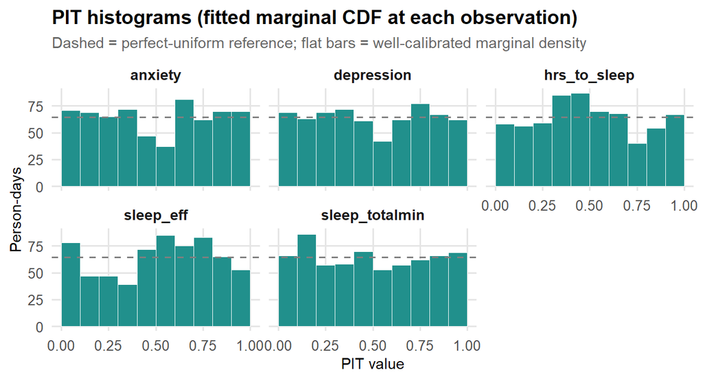

```r
ggplot(pit_long, aes(pit)) +
  geom_histogram(breaks = seq(0, 1, by = 0.1), fill = "#21908C",
                 colour = "white", linewidth = 0.2) +
  geom_hline(yintercept = nrow(X) / 10, linetype = 2, colour = "grey50") +
  facet_wrap(~ feature, ncol = 3) +
  labs(title = "PIT histograms (fitted marginal CDF at each observation)",
       subtitle = "Dashed = perfect-uniform reference; flat bars = well-calibrated marginal density",
       x = "PIT value", y = "Person-days") +
  theme_hw()
```

```r
## 2.9.4 Person-blocked cross-validated log-likelihood across K ##

#2.9.4.1 5 folds of SUBJECTS (never split a person across train/test), so the
#        score asks: does the K-state density generalize to unseen PEOPLE?
#        Standardization is re-estimated within each training fold and projected
#        onto the test fold (for no leakage)
set.seed(cfg$gmm$seed)
subj_all <- unique(person_id)
folds <- split(sample(subj_all), rep_len(1:5, length(subj_all)))
k_cv <- 1:6
n_restarts_cv <- 10L   # fewer restarts per fold to bound runtime; stability ok per 2.9.1

M_raw <- as.matrix(model_df[, feat_model])
cv_rows <- list(); i <- 0L

for (K in k_cv) {

  for (f in seq_along(folds)) {
    te_idx <- person_id %in% folds[[f]]
    Ztr <- zscore_matrix(M_raw[!te_idx, , drop = FALSE])
    Zte <- sweep(sweep(M_raw[te_idx, , drop = FALSE], 2L, attr(Ztr, "center"), "-"), 2L, attr(Ztr, "scale"), "/")
    fit_f <- gmm_em_fit(
      Ztr,
      K,
      n_restarts = n_restarts_cv,
      max_iter = cfg$gmm$max_iter,
      tol = cfg$gmm$tol,
      ridge = cfg$gmm$ridge,
      seed = cfg$gmm$seed + 100L * K + f)

    i <- i + 1L
    cv_rows[[i]] <- data.frame(
      K = K,
      fold = f,
      n_test = sum(te_idx),
      ll = gmm_loglik(fit_f, Zte))
  }
}

#2.9.4.2 Mean held-out log-likelihood PER PERSON-DAY (comparable across folds of
#        different sizes), with across-fold SE
cv <- do.call(rbind, cv_rows) |>
  dplyr::mutate(ll_per_day = ll / n_test) |>
  dplyr::group_by(K) |>
  dplyr::summarise(mean_ll = mean(ll_per_day),
                   se_ll = stats::sd(ll_per_day) / sqrt(dplyr::n()),
                   .groups = "drop")

k_cv_best <- cv$K[which.max(cv$mean_ll)]

message(glue::glue(
  "Person-blocked CV: held-out log-lik/day peaks at K = {k_cv_best} ",
  "(chosen K = {chosen_k})."))
```

```
Person-blocked CV: held-out log-lik/day peaks at K = 4 (chosen K = 4).
```

```r
nice_tbl(cv, digits = 3,
         caption = "Held-out log-likelihood per person-day by K (5-fold, person-blocked)")
```

Held-out log-likelihood per person-day by K (5-fold, person-blocked)

| K | mean_ll | se_ll |
| --- | --- | --- |
| 1 | -6.887 | 0.284 |
| 2 | -6.712 | 0.256 |
| 3 | -6.540 | 0.255 |
| 4 | -6.505 | 0.285 |
| 5 | -6.592 | 0.333 |
| 6 | -6.631 | 0.317 |

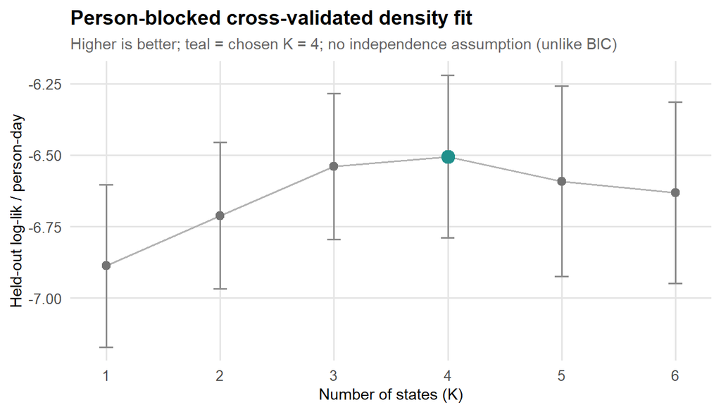

```r
ggplot(cv, aes(K, mean_ll)) +
  geom_line(colour = "grey70", linewidth = 0.6) +
  geom_errorbar(aes(ymin = mean_ll - se_ll, ymax = mean_ll + se_ll),
                width = 0.12, colour = "grey55") +
  geom_point(size = 2.4, colour = "grey45") +
  geom_point(data = dplyr::filter(cv, K == chosen_k), size = 4, colour = "#21908C") +
  scale_x_continuous(breaks = k_cv) +
  labs(title = "Person-blocked cross-validated density fit",
       subtitle = glue::glue("Higher is better; teal = chosen K = {chosen_k}; ",
                             "no independence assumption (unlike BIC)"),
       x = "Number of states (K)", y = "Held-out log-lik / person-day") +
  theme_hw()
```

## 3. State characterization, SI overlay, and dynamics

```r
## 3.1 MAP-assign states and overlay SI prevalence (+ commission) per state ##

model_df$state <- factor(gmm_map_assign(best))

overlay_vars <- intersect(c(cfg$overlay$primary, cfg$overlay$secondary, cfg$overlay$rare),
                          names(model_df))
state_overlay <- model_df |>
  dplyr::group_by(state) |>
  dplyr::summarise(n_days = dplyr::n(),
                   dplyr::across(dplyr::all_of(overlay_vars), ~ mean(.x, na.rm = TRUE)),
                   .groups = "drop")

nice_tbl(state_overlay, digits = 3, caption = "SI/SB (and commission overlay) profile by latent state")
```

SI/SB (and commission overlay) profile by latent state

| state | n_days | si_any | si_severity | si_bother | commission | ACTIVESIWITHINTENT | SELFHARM | SUICIDEATTEMPT |
| --- | --- | --- | --- | --- | --- | --- | --- | --- |
| 1 | 216 | 0.591 | 0.940 | 43.598 | 0.022 | 1.071 | 0.023 | 0.000 |
| 2 | 193 | 0.073 | 0.084 | 6.018 | 0.026 | 1.000 | 0.000 | 0.000 |
| 3 | 26 | 0.423 | 0.615 | 27.692 | 0.020 | 1.000 | 0.038 | 0.000 |
| 4 | 209 | 0.292 | 0.383 | 19.202 | 0.018 | 1.017 | 0.005 | 0.005 |

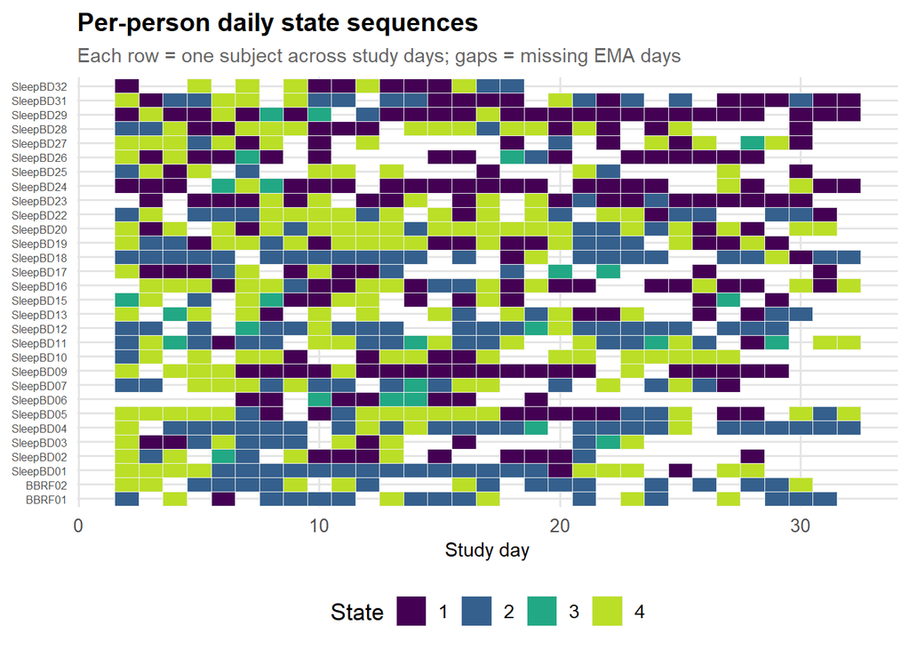

```r
## 3.2 Stage 3a: per-person state sequences, dwell times, transitions ##

#3.2.1 Decode each subject's MAP-state sequence ordered by study day. `day` is a
#      1-30 study-day index, so consecutive days differ by exactly 1; a larger
#      gap is a missed EMA day and must NOT be read as a transition
seq_df <- model_df |>
  dplyr::mutate(state = as.integer(as.character(state))) |>
  dplyr::arrange(subject, day) |>
  dplyr::group_by(subject) |>
  dplyr::mutate(prev_state = dplyr::lag(state),
                prev_day = dplyr::lag(day),
                consecutive = !is.na(prev_day) & (day - prev_day == 1L)) |>
  dplyr::ungroup()

#3.2.2 Person x day state raster: each row a subject, each column a study day,
#      coloured by MAP state (blank = missing day)
ggplot(seq_df, aes(day, factor(subject), fill = factor(state))) +
  geom_tile(colour = "grey95", linewidth = 0.2) +
  scale_fill_viridis_d(end = 0.9, name = "State") +
  labs(title = "Per-person daily state sequences",
       subtitle = "Each row = one subject across study days; gaps = missing EMA days",
       x = "Study day", y = NULL) +
  theme_hw() + theme(axis.text.y = element_text(size = 6))
```

```r
#3.2.2a Sequence descriptives for the raster: switch rate (fraction of
#       consecutive-day pairs that change state), states visited per person, and
#       transitions per person. These quantify the "rapid reconfiguration" the
#       raster shows. Computed over consecutive observed days only
switch_rate <- with(seq_df[seq_df$consecutive, ],
                    mean(state != prev_state))

per_person_seq <- seq_df |>
  dplyr::group_by(subject) |>
  dplyr::summarise(
    n_days = dplyr::n(),
    states_visited = dplyr::n_distinct(state),
    transitions = sum(consecutive & (state != prev_state), na.rm = TRUE),
    .groups = "drop")

seq_summary <- tibble::tibble(
  metric = c("Switch rate (consecutive-day pairs changing state)",
             "States visited per person (median [range])",
             "States visited per person (mean)",
             "Transitions per person (median [range])",
             "Transitions per person (mean)"),
  value = c(
    sprintf("%.1f%%", 100 * switch_rate),
    sprintf("%d [%d-%d]", stats::median(per_person_seq$states_visited),
            min(per_person_seq$states_visited), max(per_person_seq$states_visited)),
    sprintf("%.1f", mean(per_person_seq$states_visited)),
    sprintf("%d [%d-%d]", stats::median(per_person_seq$transitions),
            min(per_person_seq$transitions), max(per_person_seq$transitions)),
    sprintf("%.1f", mean(per_person_seq$transitions))))

nice_tbl(seq_summary, caption = "Per-person state-sequence descriptives (Figure: state raster)")
```

Per-person state-sequence descriptives (Figure: state raster)

| metric | value |
| --- | --- |
| Switch rate (consecutive-day pairs changing state) | 47.3% |
| States visited per person (median [range]) | 3 [2-4] |
| States visited per person (mean) | 3.2 |
| Transitions per person (median [range]) | 7 [3-15] |
| Transitions per person (mean) | 7.6 |

```r
message(glue::glue(
  "Sequence descriptives: switch rate = {round(100*switch_rate,1)}%; ",
  "states/person median {stats::median(per_person_seq$states_visited)} ",
  "(range {min(per_person_seq$states_visited)}-{max(per_person_seq$states_visited)}); ",
  "transitions/person mean {round(mean(per_person_seq$transitions),1)}."))
```

```
Sequence descriptives: switch rate = 47.3%; states/person median 3 (range 2-4); transitions/person mean 7.6.
```

```r
#3.2.2b Assignment confidence: mean max-responsibility per state. Values near 1
#       mean confident hard assignments (well-separated states); values near 1/K
#       mean fuzzy assignments, in which case rapid day-to-day "switching" is
#       partly soft-assignment noise rather than true state change
conf_df <- tibble::tibble(state = factor(gmm_map_assign(best)),
                          max_resp = gmm_max_resp(best)) |>
  dplyr::group_by(state) |>
  dplyr::summarise(
    n_days = dplyr::n(),
    mean_max_resp = round(mean(max_resp), 3),
    pct_confident = round(100 * mean(max_resp > 0.8), 1),
    .groups = "drop")

nice_tbl(conf_df,
         caption = glue::glue("MAP-assignment confidence per state (1/K = {round(1/best$K, 2)} ",
                              "= chance; >0.8 = confident)"))
```

MAP-assignment confidence per state (1/K = 0.25 = chance; >0.8 = confident)

| state | n_days | mean_max_resp | pct_confident |
| --- | --- | --- | --- |
| 1 | 216 | 0.951 | 93.5 |
| 2 | 193 | 0.915 | 85.0 |
| 3 | 26 | 0.959 | 92.3 |
| 4 | 209 | 0.919 | 86.1 |

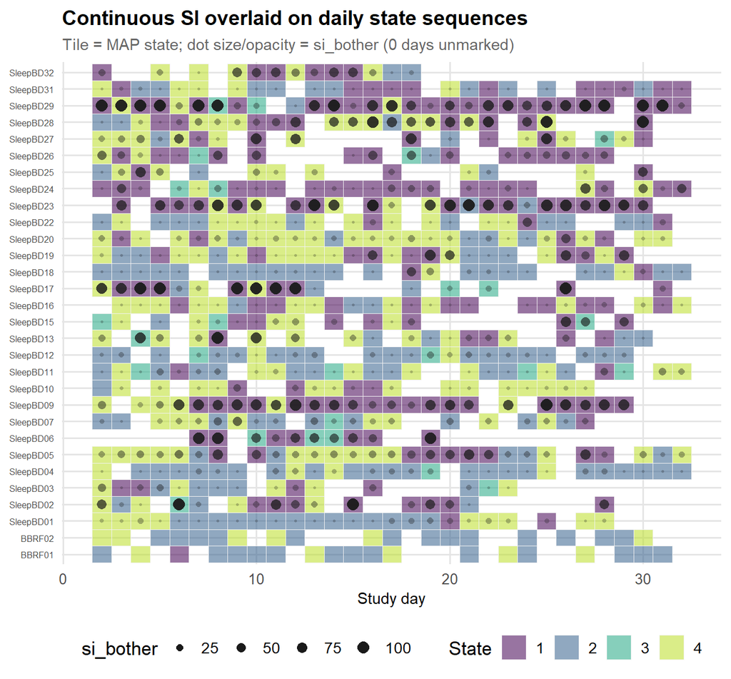

```r
## 3.2b SI overlaid on the per-person state raster ##

#3.2b.1 Two separate figures so neither encoding is squeezed: (A) the primary
#       CONTINUOUS metric (si_bother) as a size/opacity dot overlay; (B) the
#       BINARY events on one panel, distinguished by SHAPE. Deliberately omitted:
#       si_severity (near-collinear with si_bother, and is the same construct, coarser
#       scale) and ACTIVESIWITHINTENT
si_cont_metric <- "si_bother"
si_event_vars  <- intersect(c("si_any", "SELFHARM", "SUICIDEATTEMPT"), names(seq_df))

#3.2b.2 FIGURE A: state raster + continuous SI dots. Tile = MAP state
#       dot size AND opacity scale with the day's si_bother, so high-SI
#       days pop and zero-SI days vanish
ggplot(seq_df, aes(day, factor(subject))) +
  geom_tile(aes(fill = factor(state)), colour = "grey95",
            linewidth = 0.15, alpha = 0.55) +
  geom_point(data = dplyr::filter(seq_df, !is.na(.data[[si_cont_metric]]),
                                  .data[[si_cont_metric]] > 0),
             aes(size = .data[[si_cont_metric]], alpha = .data[[si_cont_metric]]),
             shape = 16, colour = "grey10") +
  scale_fill_viridis_d(end = 0.9, name = "State") +
  scale_size_continuous(range = c(0.5, 3.4), name = si_cont_metric) +
  scale_alpha_continuous(range = c(0.25, 0.95), guide = "none") +
  labs(title = "Continuous SI overlaid on daily state sequences",
       subtitle = glue::glue("Tile = MAP state; dot size/opacity = {si_cont_metric} (0 days unmarked)"),
       x = "Study day", y = NULL) +
  theme_hw() + theme(axis.text.y = element_text(size = 6))
```

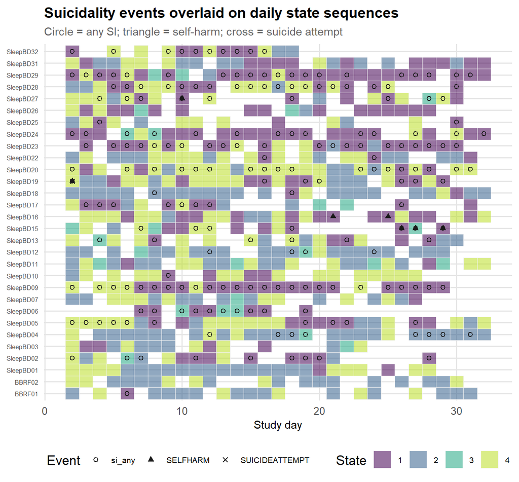

```r
#3.2b.3 FIGURE B: binary suicidality EVENTS on the same raster, one panel,
#       distinguished by shape (legend). Plotted rarest-last so attempts/self-
#       harm sit on top of the (frequent) si_any marks
events_long <- seq_df |>
  dplyr::select(subject, day, state, dplyr::all_of(si_event_vars)) |>
  tidyr::pivot_longer(dplyr::all_of(si_event_vars),
                      names_to = "event", values_to = "v") |>
  dplyr::filter(!is.na(v), v > 0) |>
  dplyr::mutate(event = factor(event, levels = c("si_any", "SELFHARM", "SUICIDEATTEMPT")))

ggplot(seq_df, aes(day, factor(subject))) +
  geom_tile(aes(fill = factor(state)), colour = "grey95",
            linewidth = 0.15, alpha = 0.55) +
  geom_point(data = events_long, aes(shape = event), size = 1.7,
             stroke = 0.7, colour = "grey10") +
  scale_fill_viridis_d(end = 0.9, name = "State") +
  scale_shape_manual(values = c(si_any = 1, SELFHARM = 17, SUICIDEATTEMPT = 4),
                     name = "Event", drop = FALSE) +
  labs(title = "Suicidality events overlaid on daily state sequences",
       subtitle = "Circle = any SI; triangle = self-harm; cross = suicide attempt",
       x = "Study day", y = NULL) +
  theme_hw() + theme(axis.text.y = element_text(size = 6), legend.text = element_text(size = 8))
```

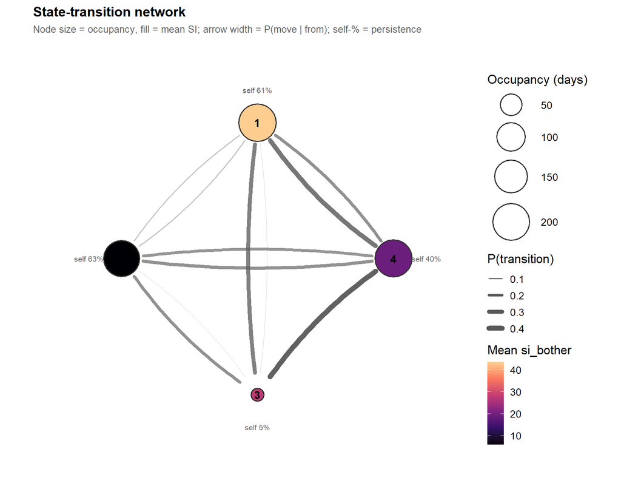

```r
## 3.2c State-transition structure: network + exact-probability heatmap ##

#3.2.3 Transition structure over CONSECUTIVE-day pairs only (row = from, col = to).
#      Row-normalized => empirical transition probabilities; the diagonal is
#      state persistence
trans <- seq_df |>
  dplyr::filter(consecutive) |>
  dplyr::count(from = prev_state, to = state) |>
  tidyr::complete(from = seq_len(best$K), to = seq_len(best$K), fill = list(n = 0L)) |>
  dplyr::group_by(from) |>
  dplyr::mutate(prob = n / sum(n)) |>
  dplyr::ungroup()

#3.2.3a Network layout: lay the K states on a circle. Node SIZE = how often the
#       state is occupied; node FILL = that state's mean SI, so the high-risk
#       state is visually obvious; directed curved EDGES = between-state
#       transition probability
si_metric_net <- if ("si_bother" %in% names(model_df)) "si_bother" else cfg$overlay$primary[1]
state_i_all <- as.integer(as.character(model_df$state))
ang <- (seq_len(best$K) - 1) / best$K * 2 * pi + pi / 2     # start at top
nodes <- tibble::tibble(
  state = seq_len(best$K),
  x = cos(ang), y = sin(ang),
  occupancy = as.numeric(table(factor(state_i_all, levels = seq_len(best$K)))),
  si = vapply(seq_len(best$K), function(s)
    mean(model_df[[si_metric_net]][state_i_all == s], na.rm = TRUE), numeric(1)))

#3.2.3b Off-diagonal edges only (between-state moves); drop near-zero edges so the
#       graph isn't a hairball. A perpendicular midpoint offset bends each edge so
#       opposing arrows (i->j vs j->i) don't overlap
edges <- trans |>
  dplyr::filter(from != to, prob > 0.02) |>
  dplyr::left_join(dplyr::rename(nodes, from = state, x0 = x, y0 = y), by = "from") |>
  dplyr::left_join(dplyr::rename(nodes, to = state, x1 = x, y1 = y), by = "to") |>
  dplyr::mutate(
    mx = (x0 + x1) / 2, my = (y0 + y1) / 2,
    nx = -(y1 - y0), ny = (x1 - x0), len = sqrt(nx^2 + ny^2),
    cx = mx + 0.12 * nx / len, cy = my + 0.12 * ny / len,   # bend control point
    a0 = atan2(cy - y0, cx - x0), a1 = atan2(cy - y1, cx - x1),
    x0t = x0 + 0.16 * cos(a0), y0t = y0 + 0.16 * sin(a0),   # trim off node centers
    x1t = x1 + 0.16 * cos(a1), y1t = y1 + 0.16 * sin(a1))

#3.2.3c Quadratic-Bezier polylines for each curved edge
bez <- function(p0, p1, p2, n = 30) {
  t <- seq(0, 1, length.out = n)
  (1 - t)^2 * p0 + 2 * (1 - t) * t * p1 + t^2 * p2
}

edge_paths <- if (nrow(edges) > 0) do.call(rbind, lapply(seq_len(nrow(edges)), function(i) {
  e <- edges[i, ]
  data.frame(id = i, prob = e$prob,
             x = bez(e$x0t, e$cx, e$x1t), y = bez(e$y0t, e$cy, e$y1t))
})) else NULL

#3.2.3c.1 arrowhead = last segment of each edge path
heads <- if (!is.null(edge_paths)) edge_paths |>
  dplyr::group_by(id) |>
  dplyr::slice_tail(n = 2) |>
  dplyr::summarise(prob = dplyr::first(prob),
                   x = dplyr::nth(x, 1), y = dplyr::nth(y, 1),
                   xend = dplyr::nth(x, 2), yend = dplyr::nth(y, 2),
                   .groups = "drop") else NULL

#3.2.3d Self-persistence (diagonal) annotated just outside each node
self_p <- trans |> dplyr::filter(from == to) |>
  dplyr::select(state = from, p_self = prob) |>
  dplyr::right_join(nodes, by = "state")

net <- ggplot()

if (!is.null(edge_paths)) {
  net <- net +
    geom_path(data = edge_paths,
              aes(x, y, group = id, linewidth = prob, alpha = prob),
              colour = "grey35", lineend = "round") +
    geom_segment(data = heads,
                 aes(x = x, y = y, xend = xend, yend = yend, alpha = prob),
                 arrow = grid::arrow(length = grid::unit(0.16, "cm"), type = "closed"),
                 colour = "grey35", linewidth = 0.4, show.legend = FALSE)
}

net +
  geom_point(data = nodes, aes(x, y, size = occupancy, fill = si),
             shape = 21, colour = "grey20", stroke = 0.8) +
  geom_text(data = nodes, aes(x, y, label = state), fontface = "bold", size = 4) +
  geom_text(data = self_p, aes(x * 1.24, y * 1.24,
            label = sprintf("self %.0f%%", 100 * p_self)), size = 2.8, colour = "grey40") +
  scale_linewidth_continuous(range = c(0.3, 2.6), name = "P(transition)") +
  scale_alpha_continuous(range = c(0.25, 0.95), guide = "none") +
  scale_size_continuous(range = c(6, 18), name = "Occupancy (days)") +
  scale_fill_viridis_c(option = "magma", end = 0.9, name = glue::glue("Mean {si_metric_net}")) +
  coord_equal(xlim = c(-1.5, 1.5), ylim = c(-1.5, 1.5)) +
  labs(title = "State-transition network",
       subtitle = "Node size = occupancy, fill = mean SI; arrow width = P(move | from); self-% = persistence") +
  theme_void(base_size = 13) +
  theme(plot.title = element_text(face = "bold", size = 14),
        plot.subtitle = element_text(size = 10, colour = "grey40"),
        legend.position = "right")
```

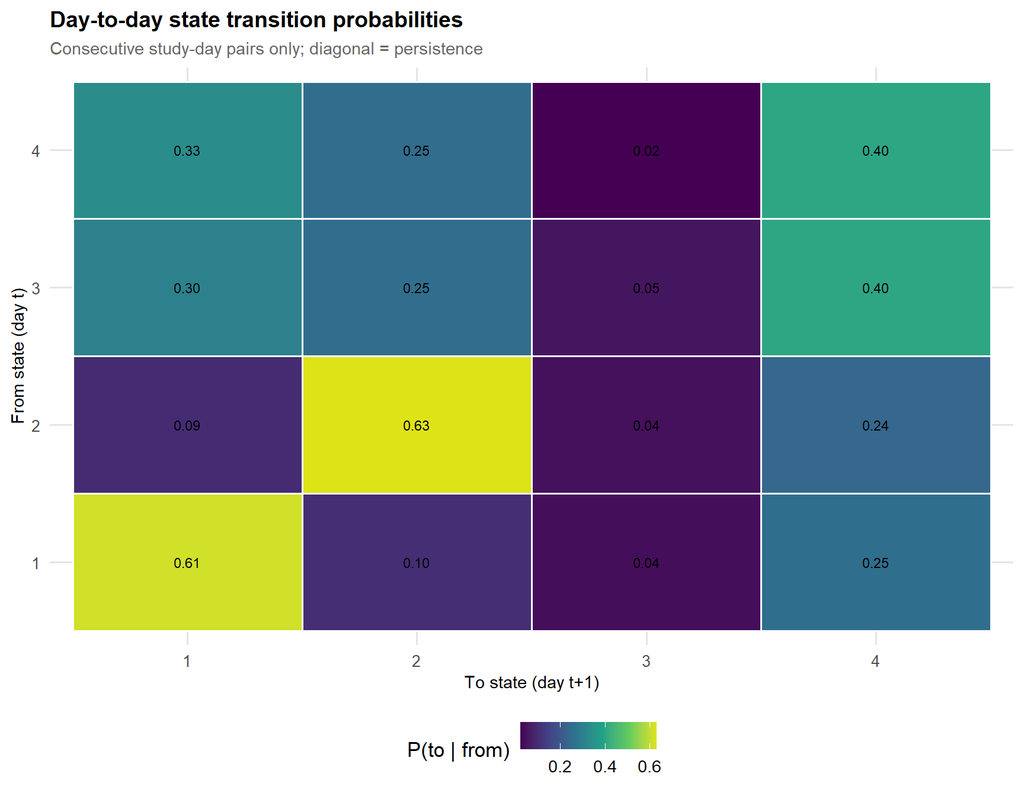

```r
#3.2.3e Companion heatmap: exact probabilities incl. the diagonal the network
#       abstracts. Network = structure at a glance; heatmap = precise values
ggplot(trans, aes(factor(to), factor(from), fill = prob)) +
  geom_tile(colour = "white", linewidth = 0.6) +
  geom_text(aes(label = ifelse(n == 0, "", sprintf("%.2f", prob))), size = 3) +
  scale_fill_viridis_c(end = 0.95, name = "P(to | from)") +
  labs(title = "Day-to-day state transition probabilities",
       subtitle = "Consecutive study-day pairs only; diagonal = persistence",
       x = "To state (day t+1)", y = "From state (day t)") +
  theme_hw()
```

```r
#3.2.3f Persistence summary: diagonal of the transition matrix (probability a
#       state is followed by itself the next day) + the single most likely
#       destination when it does change
persist_tbl <- trans |>
  dplyr::group_by(from) |>
  dplyr::summarise(
    self_transition = prob[to == from][1],
    top_exit = to[which.max(ifelse(to == from, -Inf, prob))],
    top_exit_prob = max(ifelse(to == from, -Inf, prob)),
    .groups = "drop") |>
  dplyr::mutate(self_transition = round(self_transition, 2),
                top_exit_prob = round(top_exit_prob, 2))

nice_tbl(persist_tbl,
         caption = "State persistence (self-transition probability) and most likely exit destination")
```

State persistence (self-transition probability) and most likely exit destination

| from | self_transition | top_exit | top_exit_prob |
| --- | --- | --- | --- |
| 1 | 0.61 | 4 | 0.25 |
| 2 | 0.63 | 4 | 0.24 |
| 3 | 0.05 | 4 | 0.40 |
| 4 | 0.40 | 1 | 0.33 |

```r
## 3.2d Dwell times per state ##

#3.2.4 Dwell times: lengths of maximal runs of the SAME state across consecutive
#      days (a run is broken by a state change OR a day gap), i.e. how long the
#      system typically sits in a state before moving
new_run <- !(seq_df$consecutive & seq_df$state == seq_df$prev_state)
new_run[is.na(new_run)] <- TRUE
seq_df$run <- cumsum(new_run)

dwell <- seq_df |>
  dplyr::group_by(subject, run, state) |>
  dplyr::summarise(dwell = dplyr::n(), .groups = "drop") |>
  dplyr::group_by(state) |>
  dplyr::summarise(n_runs = dplyr::n(),
                   mean_dwell = round(mean(dwell), 2),
                   max_dwell  = max(dwell), .groups = "drop")

nice_tbl(dwell, caption = "Dwell time per state (lengths of consecutive-day runs)")
```

Dwell time per state (lengths of consecutive-day runs)

| state | n_runs | mean_dwell | max_dwell |
| --- | --- | --- | --- |
| 1 | 116 | 1.86 | 11 |
| 2 | 100 | 1.93 | 14 |
| 3 | 25 | 1.04 | 2 |
| 4 | 148 | 1.41 | 6 |

### How to read the critical-slowing-down (CSD) analysis

The Scheffer theory: a system nearing a tipping point loses resilience, and after any small perturbation it drifts back to baseline more slowly. In daily data that loss of resilience leaves two statistical fingerprints in the days just before a transition: (1) rising variance, where the system wanders further before recovering, and (2) rising lag-1 autocorrelation, where today looks more like yesterday, because recovery is sluggish. The analysis below therefore takes every stretch of consecutive days, computes those two fingerprints per feature inside a short trailing window, and asks one question: *are the windows that immediately precede a within-person SI surge different from all the other windows?* In the boxplot, each facet column is a feature, the top row is the autocorrelation fingerprint and the bottom row the variance fingerprint, and within each panel the two boxes compare “pre-surge” windows against “other” windows. CSD predicts the pre-surge box sits higher in both rows. With few pre-surge windows this is direction-reading only

```r
## 3.3 Stage 3b (EXPLORATORY): critical-slowing-down before high-SI onset ##

# WHAT THIS ASKS: dynamical-systems theory (Scheffer) predicts that as a system
# approaches a tipping point, it recovers more slowly from perturbations; which
# shows up as RISING variance and RISING lag-1 autocorrelation (AC1) in the days
# just before the transition. Here the "transition" is a within-person surge in
# suicidal ideation. If CSD operates at the daily timescale, the short window of
# days immediately BEFORE an SI surge should show higher variance / AC1 in the
# mood+sleep features than ordinary windows

si_metric <- if ("si_bother" %in% names(model_df)) "si_bother" else cfg$overlay$primary[1]
ew_window <- 3L   # trailing consecutive-day window (kept short; series are brief/gappy)

#3.3.1 Define ONSET as a within-person SI SURGE rather than a categorical state
#      entry. Categorical entry into the high-SI state is too rare in these short,
#      gappy series to yield usable windows; a within-person rise in the
#      continuous SI score past that person's own median (from below it) captures
#      the same "crossing into a high-SI day" idea with far more events
si_by_person <- model_df |>
  dplyr::mutate(state_i = as.integer(as.character(state))) |>
  dplyr::group_by(subject) |>
  dplyr::mutate(si_thresh = stats::median(.data[[si_metric]], na.rm = TRUE)) |>
  dplyr::ungroup()
seq_si <- seq_df |>
  dplyr::left_join(dplyr::select(si_by_person, subject, day, si_thresh,
                                 si_now = dplyr::all_of(si_metric)),
                   by = c("subject", "day"))

#3.3.2 Slide a window of `ew_window` CONSECUTIVE days within each subject; compute
#      each feature's variance and AC1 in the window, then flag whether the day
#      immediately AFTER is an SI surge (at/above the person's median, having been
#      below it on the window's last day)
ac1 <- function(x) {
  if (length(x) < 3L || stats::sd(x) == 0) return(NA_real_)
  stats::cor(x[-length(x)], x[-1])
}

ew_rows <- list(); r <- 0L; n_windows <- 0L; n_onset <- 0L
for (sdf in split(seq_si, seq_si$subject)) {
  sdf <- sdf[order(sdf$day), ]
  if (nrow(sdf) < ew_window + 1L) next
  for (i in seq_len(nrow(sdf) - ew_window)) {
    win <- sdf[i:(i + ew_window - 1L), ]
    nxt <- sdf[i + ew_window, ]

    #3.3.2.1 window fully consecutive AND nxt adjacent to its last day
    if (any(diff(win$day) != 1L) || (nxt$day - win$day[ew_window]) != 1L) next

    #3.3.2.2 need SI present on the boundary days to define a surge
    last_si <- win$si_now[ew_window]
    if (is.na(last_si) || is.na(nxt$si_now) || is.na(nxt$si_thresh)) next
    n_windows <- n_windows + 1L
    onset <- (last_si < nxt$si_thresh) && (nxt$si_now >= nxt$si_thresh)
    if (onset) n_onset <- n_onset + 1L
    for (f in feat_model) {
      r <- r + 1L
      ew_rows[[r]] <- data.frame(feature = f,
                                 variance = stats::var(win[[f]]),
                                 ac1 = ac1(win[[f]]), onset = onset)
    }
  }
}
ew <- if (length(ew_rows)) do.call(rbind, ew_rows) else NULL

#3.3.3 FEASIBILITY FIRST: report how many windows and how many pre-onset windows
#      exist. This count determines if pre-onset windows are in the single digits
message(glue::glue(
  "Early-warning feasibility: {n_windows} valid {ew_window}-day windows, ",
  "of which {n_onset} precede a within-person SI surge ",
  "(SI metric = {si_metric})."))
```

```
Early-warning feasibility: 282 valid 3-day windows, of which 34 precede a within-person SI surge (SI metric = si_bother).
```

```r
#3.3.4 Compare indicator levels in pre-surge vs other windows. Strictly
#      hypothesis-generating: read DIRECTION (are pre-surge variance/AC1 higher?)
#      and the pre-surge n
ew_ok <- !is.null(ew) && n_onset >= 3L

if (ew_ok) {
  ew_long <- ew |>
    tidyr::pivot_longer(c(variance, ac1), names_to = "indicator", values_to = "value") |>
    tidyr::drop_na(value) |>
    dplyr::mutate(window = ifelse(onset, "pre-surge", "other"),
                  indicator = dplyr::recode(indicator,
                    variance = "variance (within-window spread)",
                    ac1 = "lag-1 autocorrelation (recovery slowing)"))

} else {
  message("Too few pre-surge windows (", n_onset,
          ") for a meaningful comparison; reporting feasibility only. ",
          "This is itself an F31 result: daily sampling is too sparse to resolve ",
          "critical slowing down, motivating denser (e.g. multi-daily) EMA.")
}

#3.3.5 Table + plot are emitted as TOP-LEVEL single-expression conditionals:
#      values created inside a multi-expression `{}` block are invisible to
#      knitr's auto-printing
if (ew_ok) nice_tbl(
  ew_long |>
    dplyr::group_by(feature, indicator, window) |>
    dplyr::summarise(n = dplyr::n(), mean = mean(value), .groups = "drop"),
  digits = 3,
  caption = glue::glue("Early-warning indicators: pre-surge vs other windows ",
                       "({ew_window}-day windows; {n_onset} pre-surge windows)"))
```

Early-warning indicators: pre-surge vs other windows (3-day windows; 34 pre-surge windows)

| feature | indicator | window | n | mean |
| --- | --- | --- | --- | --- |
| anxiety | lag-1 autocorrelation (recovery slowing) | other | 225 | -0.324 |
| anxiety | lag-1 autocorrelation (recovery slowing) | pre-surge | 28 | -0.071 |
| anxiety | variance (within-window spread) | other | 248 | 617.269 |
| anxiety | variance (within-window spread) | pre-surge | 34 | 413.951 |
| depression | lag-1 autocorrelation (recovery slowing) | other | 231 | -0.247 |
| depression | lag-1 autocorrelation (recovery slowing) | pre-surge | 32 | -0.250 |
| depression | variance (within-window spread) | other | 248 | 474.962 |
| depression | variance (within-window spread) | pre-surge | 34 | 300.127 |
| hrs_to_sleep | lag-1 autocorrelation (recovery slowing) | other | 247 | -0.279 |
| hrs_to_sleep | lag-1 autocorrelation (recovery slowing) | pre-surge | 34 | -0.412 |
| hrs_to_sleep | variance (within-window spread) | other | 248 | 9.935 |
| hrs_to_sleep | variance (within-window spread) | pre-surge | 34 | 6.945 |
| sleep_eff | lag-1 autocorrelation (recovery slowing) | other | 247 | -0.279 |
| sleep_eff | lag-1 autocorrelation (recovery slowing) | pre-surge | 33 | -0.455 |
| sleep_eff | variance (within-window spread) | other | 248 | 44.539 |
| sleep_eff | variance (within-window spread) | pre-surge | 34 | 36.619 |
| sleep_totalmin | lag-1 autocorrelation (recovery slowing) | other | 244 | -0.303 |
| sleep_totalmin | lag-1 autocorrelation (recovery slowing) | pre-surge | 34 | -0.235 |
| sleep_totalmin | variance (within-window spread) | other | 248 | 26786.089 |
| sleep_totalmin | variance (within-window spread) | pre-surge | 34 | 24995.265 |

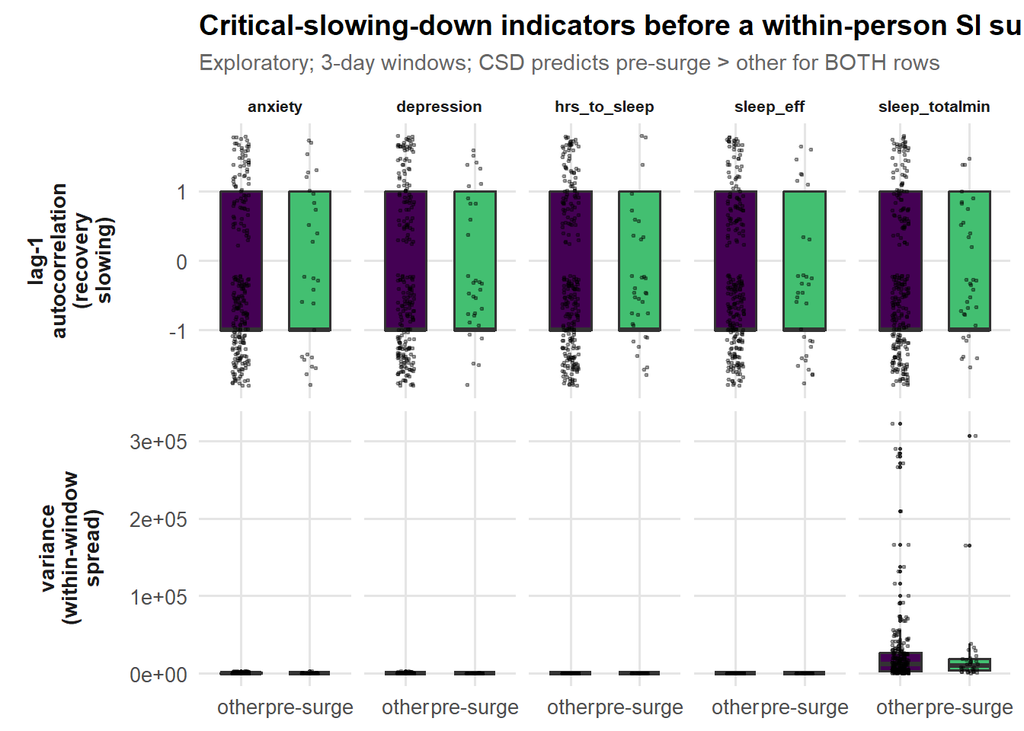

```r
if (ew_ok) ggplot(ew_long, aes(window, value, fill = window)) +
  geom_boxplot(outlier.size = 0.6, width = 0.6) +
  geom_jitter(width = 0.12, size = 0.5, alpha = 0.3) +
  facet_grid(indicator ~ feature, scales = "free_y", switch = "y",
             labeller = ggplot2::label_wrap_gen(width = 18)) +
  scale_fill_viridis_d(end = 0.7, guide = "none") +
  labs(title = "Critical-slowing-down indicators before a within-person SI surge",
       subtitle = glue::glue("Exploratory; {ew_window}-day windows; ",
                             "CSD predicts pre-surge > other for BOTH rows"),
       x = NULL, y = NULL) +
  theme_hw() +
  theme(strip.placement = "outside", strip.text.x = element_text(size = 8))
```

## Limitations

- Person-days are not independent (i.e., within-person autocorrelation; clustering in ~30 people); the GMM likelihood treats them as exchangeable, which inflates the effective N that BIC assumes and biases it toward more components. Mitigations: ICL (entropy-penalized) and the smallest-mixing-weight diagnostic alongside BIC, the person x state artifact check, and the person-mean-centered sensitivity refit (Section 2.8) isolating within-person state structure
- Commission-error rate is excluded from the mixture (documented above: ~45% zero-error days force degenerate components)
- The daily EMA mood items are depression and anxiety only, there is no daily elevated-mood/manic item, so states characterize the depressive/dysregulated axis, with the manic pole captured only indirectly (e.g., via sleep loss)
- Actigraphy was processed with the Sadeh algorithm for most but not all participants
- The Stage-3b early-warning (critical-slowing-down) analysis is exploratory and underpowered. Short, gap-interrupted per-person series yield few consecutive pre-onset windows, so it is reported as hypothesis-generating preliminary evidence for the F31, not a confirmatory test of rising variance / autocorrelation before high-SI transitions